# Doing Data Science: Case Study 2 - Forecasting Chulwalar Total Etel Exports

### Claire Chu & Joseph Stoffa

### July 19, 2016

## Introduction

Chulwalar is part of the island group Urbano in the northern hemisphere. They are famous for their plants which flower in winter. There are three main plants that Chulwalar exports: Efak is a leafy bush with white flowers, Wuge is a grass like plant with tiny pink flowers and Etel is a flowering tree. Etel comes in two varieties: red flowers and blue flowers. Due to the nature of the products, exports generally are higher towards the end of the year. Chulwalar celebrates its independence on the 1st of December each year. On this day it is custom to give presents to family and friends. Chulwalar also celebrates the March Equinox as a time of rebirth in the northern hemisphere.

The Prime Minister of Chulwalar has asked [Wheeler et al] to help him in forecasting the exports. In order to do this [Wheeler et al] were given as is data and plan data as well as a list of indicators which may affect exports. The Wheeler group’s job is to find out the best way to forecast Chulwalar’s exports in 2014 based on data collected before this year

## Background

This case study builds on the data analysis and modeling of plant exports from Chulwalar performed by Wheeler et al (outlined in Introduction) in order to find the best model to forecast total Etel exports.

## Table of Contents

#### 1.0 Importing Data

#### 2.0 Cleaning Modifying Data

#### 3.0 Exploring Data

#### —3.1 Preliminary Analysis

#### —3.2 Preliminary Time Series Analysis

#### 4.0 Correlation of Different External Indicators

#### —4.1 4.1 Definition of the Indicators and Their Correlation with the Basic Data

#### —4.2 4.2 Correlation of the Indicators with a Time Offset

#### —4.3 Correlation of the Indicators with Each Other

#### 5.0 Development of Forecasting Models

#### —5.1 ModelWithAlllIndicators and with Each Indicator Individually

#### —5.2 Models

#### 6.0 Forecasts with the models

#### —6.1 Shorten the Time Series in Order to Test the Forecasts

#### —6.2 Forecasting and Testing the Models

#### 7.0 Forecast for 2014

#### 8.0 Developing Forecasting Models with Alternative Model Approaches

#### —8.1 Exponential Smoothing

#### —8.2 ARIMA

#### —8.3 Dynamic Regression Models

#### 9.0 Conclusion

#### 10.0 Acknowledgements

## 1.0 Importing Data

The script *loadData.r* loads the the data for this case study into dataframes *ImportedAsISData*, *ImportedIndicators*, and *ImportedPlanData* from the files *ImportedAsIsDataChulwalar.csv*, *ImportedIndicatorshulwalar.csv*, and *ImportedPlanDataChulwalar.csv* respectively.

```
## [1] CSV files successfully read.  Dataframes loaded:
## [1] ImportedAsIsData   ImportedIndicators ImportedPlanData
```

## 2.0 Cleaning/Modifying Data

In order to conduct our analysis the data needs to be subsetted into vectors and time series. For this case study we are only interested in the Total Etel exports. Data on other individual plants will be ignored. The script *cleanData.r* takes the data frames for As Is, Planned, and Indicator data and splits them into vectors which are then converted into time series. Below are the resultant time series outputted by the script.

```r
source("Scripts/cleanData.r")
```

```
## [1] TotalAsIs:
##          Jan     Feb     Mar     Apr     May     Jun     Jul     Aug
## 2008 2313221 1950131 2346635 2039787 1756964 1458302 1679637 1639670
## 2009 2610573 2371327 2743786 2125308 1850073 1836222 1797311 1851968
## 2010 2760688 2918333 3227041 1613888 2550157 2317645 1474144 2148521
## 2011 3112861 2926663 3294784 2577079 2774068 2378227 2222900 2991787
## 2012 3093088 3679308 3433364 2714899 3011767 2726028 2483834 3055655
## 2013 4119526 3535744 3560974 3760065 2959933 2787898 2828744 3084113
##          Sep     Oct     Nov     Dec
## 2008 2882886 2959716 2596494 2656568
## 2009 3271171 2818888 3310776 3022513
## 2010 3898571 3348953 3135945 3332886
## 2011 4151531 3318684 4037076 3429843
## 2012 4200796 4228724 4618540 3383673
## 2013 5107775 4562144 4729313 4372181
```

[output cut: 92 more lines]

## 3.0 Exploring Data

### 3.1 Preliminary Analysis

For the preliminary Analysis, the time series have been plotted and the correlation between the As Is and Plan data has been tested in order to ascertain how exact the planning is. These results show a very high planning accuracy and are therefore suitable for modeling. (Wheeler et al.)

```r
source("Scripts/preliminaryAnalysis.r")
```

```
## [1] Correlation between Total As Is and Total Plan:
## [1] 0.9183402
## [1] Correlation between Total Etel As Is and Total Etel Plan:
## [1] 0.9159505
## [1] Correlation between Year As Is and Year Plan:
## [1] 0.9627401
##
## Call:
## lm(formula = TotalAsIs ~ TotalPlan, data = TotalAsIs)
##
## Residuals:
##     Min      1Q  Median      3Q     Max
## -770214 -196776   26017  182579  672705
##
## Coefficients:
##              Estimate Std. Error t value Pr(>|t|)
## (Intercept) 8.959e+04  1.521e+05   0.589    0.558
## TotalPlan   9.627e-01  4.959e-02  19.413   <2e-16 ***
## ---
## Signif. codes:  0 '***' 0.001 '**' 0.01 '*' 0.05 '.' 0.1 ' ' 1
##
## Residual standard error: 332600 on 70 degrees of freedom
## Multiple R-squared:  0.8433, Adjusted R-squared:  0.8411
## F-statistic: 376.9 on 1 and 70 DF,  p-value: < 2.2e-16
##
##
## Call:
## tslm(formula = TotalAsIs ~ TotalPlan)
##
## Residuals:
##     Min      1Q  Median      3Q     Max
## -770214 -196776   26017  182579  672705
##
## Coefficients:
##              Estimate Std. Error t value Pr(>|t|)
## (Intercept) 8.959e+04  1.521e+05   0.589    0.558
## TotalPlan   9.627e-01  4.959e-02  19.413   <2e-16 ***
## ---
## Signif. codes:  0 '***' 0.001 '**' 0.01 '*' 0.05 '.' 0.1 ' ' 1
##
## Residual standard error: 332600 on 70 degrees of freedom
## Multiple R-squared:  0.8433, Adjusted R-squared:  0.8411
## F-statistic: 376.9 on 1 and 70 DF,  p-value: < 2.2e-16
```

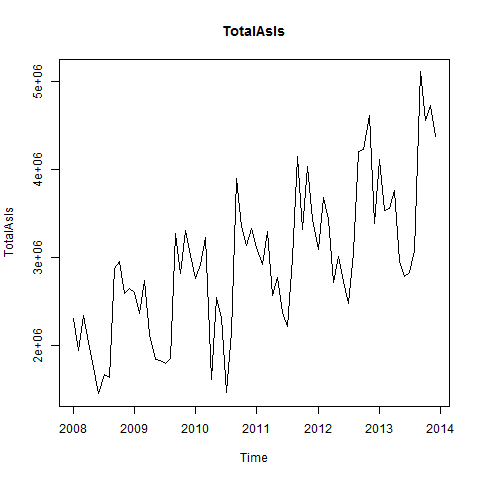

Figure 1

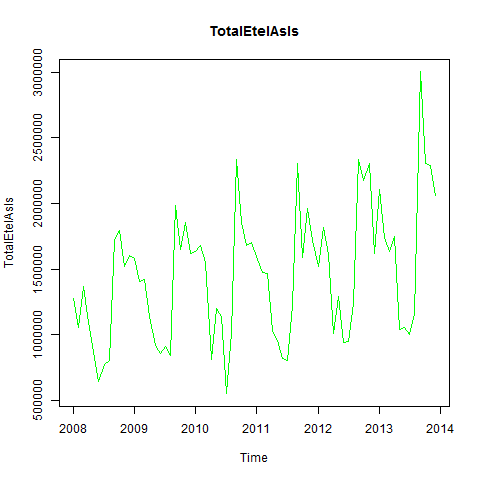

Figure 2

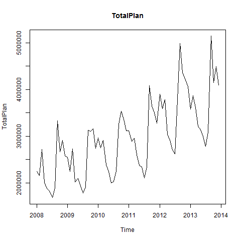

Figure 3

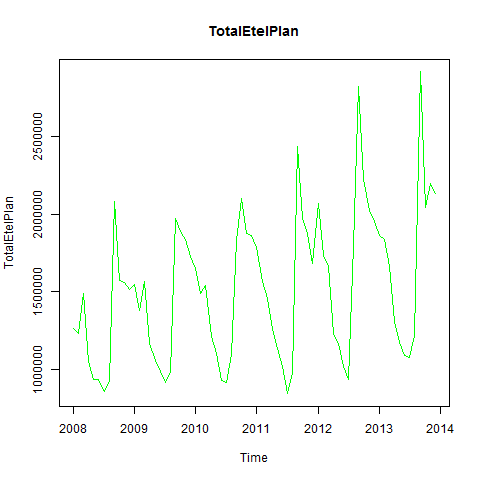

Figure 4

### 3.2 Preliminary Time Series Analysis

The time series can be analyzed using the *stl* function in order to seperate the trend, seasonality, and remainder (remaining) coincidental) components from one another. Thus the individual time series can be shown graphically and tabularly. The trend of the total exports is almost linear. A relatively uniform seasonality can be seen in Figure 5. (Wheeler et al).

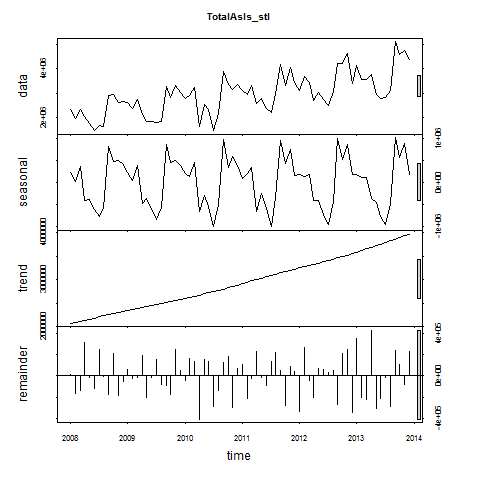

Figure 5

```r
print(TotalAsIs_stl)
```

```
##  Call:
##  stl(x = TotalAsIs, s.window = 5)
##
## Components
##             seasonal   trend  remainder
## Jan 2008   223320.67 2074233   15667.16
## Feb 2008    17036.99 2096208 -163113.80
## Mar 2008   361473.74 2118182 -133021.18
## Apr 2008  -410834.24 2140157  310464.16
## May 2008  -391831.93 2162114  -13317.80
## Jun 2008  -608564.13 2184070 -117204.25
## Jul 2008  -777993.52 2206027  251603.49
## Aug 2008  -583615.66 2228213   -4927.72
## Sep 2008   810939.36 2250400 -178453.09
## Oct 2008   474131.86 2272586  212998.05
## Nov 2008   488504.52 2294373 -186383.79
## Dec 2008   395452.58 2316160  -55045.03
## Jan 2009   217151.38 2337948   55473.99
## Feb 2009    39716.91 2359168  -27558.10
## Mar 2009   378507.21 2380389  -15109.96
## Apr 2009  -467522.18 2401609  191220.87
## May 2009  -371597.89 2425515 -203844.26
## Jun 2009  -595724.45 2449421  -17474.54
## Jul 2009  -827029.12 2473327  151013.28
## Aug 2009  -567342.69 2495885  -76573.99
## Sep 2009   843160.68 2518443  -90432.21
## Oct 2009   447562.71 2541000 -169675.09
## Nov 2009   497312.47 2562364  251099.75
## Dec 2009   388265.67 2583727   50520.14
## Jan 2010   201133.54 2605091  -45536.12
## Feb 2010   122776.46 2628120  167436.40
## Mar 2010   442825.47 2651150  133065.83
## Apr 2010  -652923.75 2674179 -407367.50
## May 2010  -301149.68 2698691  152615.46
## Jun 2010  -543850.29 2723203  138292.09
## Jul 2010  -985987.99 2747715 -287583.18
## Aug 2010  -487941.31 2774544 -138081.68
## Sep 2010   972415.73 2801373  124782.46
## Oct 2010   343206.82 2828202  177544.55
## Nov 2010   573281.74 2858572 -295909.05
```

[output cut: 22 more lines]

```
## Oct 2012   523934.85 3497123  207665.66
## Nov 2012   847979.72 3527674  242886.44
## Dec 2012   172550.29 3558224 -347101.49
## Jan 2013   184195.89 3588775  346555.55
## Feb 2013   114297.14 3623803 -202355.91
## Mar 2013   121000.80 3658831 -218857.78
## Apr 2013  -360531.42 3693859  426737.22
## May 2013  -462506.26 3728897 -306457.92
## Jun 2013  -759940.89 3763935 -216096.28
## Jul 2013  -951772.71 3798973  -18456.45
## Aug 2013  -468011.67 3834192 -282067.53
## Sep 2013  1004335.28 3869411  234028.47
## Oct 2013   554713.70 3904630  102800.01
## Nov 2013   873598.66 3940742  -85027.53
## Dec 2013   169104.03 3976853  226223.51
```

It is interesting to note that the almost linear trend is not seen in the individual segment for Total Etel (Figure 6). The individual trends for all flower exports run in partially opposite directions in the middle of the time scale, which causes the total As Is data trend to be linear. (Wheeler et al).

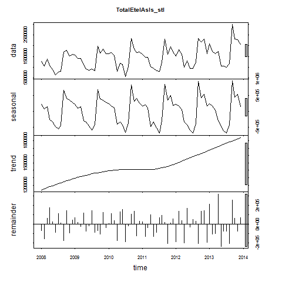

Figure 6

```r
print(TotalEtelAsIs_stl)
```

```
##  Call:
##  stl(x = TotalEtelAsIs, s.window = 5)
##
## Components
##            seasonal   trend   remainder
## Jan 2008  212543.90 1135393  -68268.686
## Feb 2008   64724.69 1149373 -160772.697
## Mar 2008  141647.42 1163353   62519.359
## Apr 2008 -264999.95 1177333  178391.504
## May 2008 -339776.29 1191010   22334.080
## Jun 2008 -473456.92 1204687  -86751.057
## Jul 2008 -560479.22 1218364  114773.472
## Aug 2008 -439963.23 1231709   14995.207
## Sep 2008  649360.43 1245054 -179149.730
## Oct 2008  394715.11 1258400  142636.314
## Nov 2008  343804.99 1270718  -96234.645
## Dec 2008  272635.02 1283036   45653.230
## Jan 2009  216526.66 1295354   71335.502
## Feb 2009   85366.77 1304840   17181.430
## Mar 2009  134597.06 1314326  -28121.833
## Apr 2009 -299576.10 1323812  116864.362
## May 2009 -339425.04 1333273  -73988.443
## Jun 2009 -463451.32 1342735  -20407.903
## Jul 2009 -588086.05 1352197  146023.090
## Aug 2009 -428334.97 1359570  -88185.300
## Sep 2009  684000.28 1366944  -69380.862
## Oct 2009  378107.74 1374317 -104490.629
## Nov 2009  350361.28 1380061  127414.131
## Dec 2009  269269.49 1385804  -39982.767
## Jan 2010  237811.58 1391548    8104.442
## Feb 2010  164697.76 1396069  115393.780
## Mar 2010  108887.92 1400591   40081.142
## Apr 2010 -414588.58 1405112 -177054.835
## May 2010 -341339.97 1406966  132774.500
## Jun 2010 -426196.92 1408821  157400.399
## Jul 2010 -672372.03 1410675 -187034.545
## Aug 2010 -377863.24 1410092  -19686.420
## Sep 2010  818966.77 1409509  107012.482
## Oct 2010  310866.57 1408926  136471.594
## Nov 2010  396380.37 1408474 -126731.546
```

[output cut: 22 more lines]

```
## Oct 2012  411978.67 1626922  138994.561
## Nov 2012  520321.23 1641216  144786.748
## Dec 2012  157545.15 1655510 -194908.427
## Jan 2013  228279.54 1669805  211412.939
## Feb 2013  159093.45 1685663 -106559.227
## Mar 2013   32529.79 1701521 -100106.827
## Apr 2013 -295207.15 1717379  322919.852
## May 2013 -454478.79 1733056 -239128.325
## Jun 2013 -615888.66 1748733  -78643.269
## Jul 2013 -688356.21 1764410  -72887.536
## Aug 2013 -417329.54 1779986 -207981.755
## Sep 2013  944212.59 1795563  261153.561
## Oct 2013  431257.90 1811139   63207.703
## Nov 2013  530407.87 1827035  -72771.039
## Dec 2013  148706.84 1842931   70522.228
```

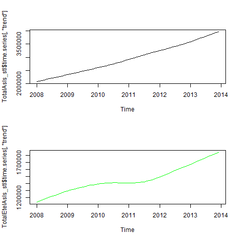

Figure 7

The modification of the seasonality component can also be changed into a montly view. It only makes sense to do this if the seasonality component as the trend looks almost identical and the remainder is then randomly spread. (Wheeler et al.)

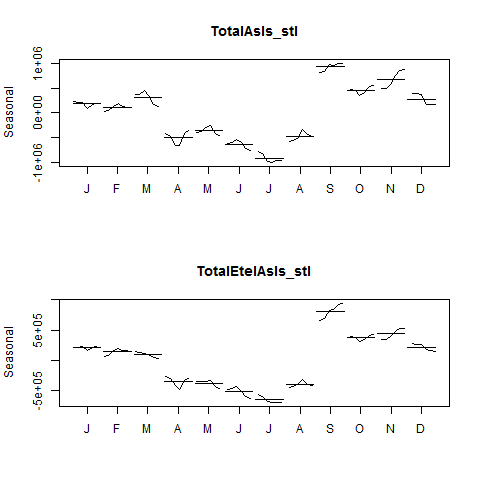

Figure 8

## 4.0 Correlation of Different External Indicators

### 4.1 Definition of the Indicators and Their Correlation with the Basic Data

The following indicators are to be tested:

1. Monthly Change in Export Price Index (CEPI)
2. Monthly Satisfaction Index (SI) government based data
3. Average monthly temperatures in Chulwalar
4. Monthly births in Chulwalar
5. Monthly Satisfaction Index (SI) external index
6. Yearly Exports from Urbano
7. Yearly number of Globalisation Party members in Chulwalar
8. Monthly Average Export Price Index for Chulwalar
9. Monthly Producer Price Index (PPI) for Etel in Chulwalar
10. National Holidays
11. Chulwalar Index (Total value of all companies in Chulwalar)
12. Monthly Inflation rate in Chulwalar
13. Proposed spending for National Holidays
14. Influence of National Holiday

The indicators will be converted into individual vectors and subsequently converted into time series. The correlation of the indicators will then be tested against the As Is exports for Chulwalar.

```r
source("Scripts/correlateIndicators.r")
```

#### Monthly Changine in Export Price (CEPI):

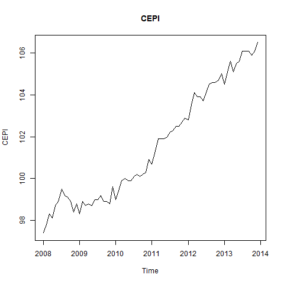

Figure 9

```r
#check correlation of CEPI
print(cor(TotalAsIs, CEPI))
```

```
## [1] 0.663925
```

```r
print(cor(TotalEtelAsIs, CEPI))
```

```
## [1] 0.339713
```

The CEPI correlates very well with the efak exports.

#### Monthly Satisfaction Index (SI) Government Based Data:

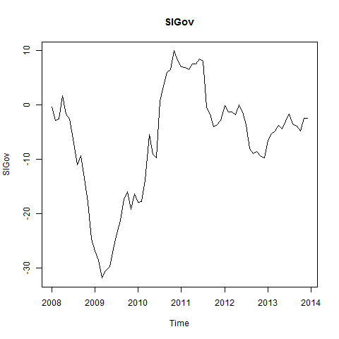

Figure 10

```r
#check correlation of SIGov
print(cor(TotalAsIs, SIGov))
```

```
## [1] 0.2007768
```

```r
print(cor(TotalEtelAsIs, SIGov))
```

```
## [1] 0.002556094
```

The Satisfaction Index does not show any particular correlation with any of the exports data.

#### Average Monthly Temperatures in Chulwalar:

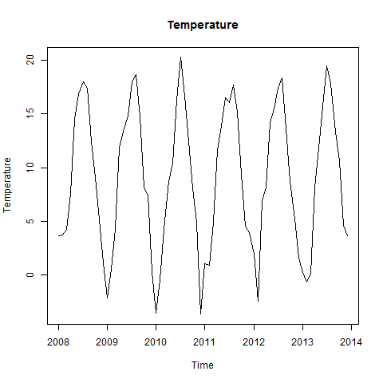

Figure 11

```r
#check correlation of Temperature
print(cor(TotalAsIs, Temperature))
```

```
## [1] -0.3429684
```

```r
print(cor(TotalEtelAsIs, Temperature))
```

```
## [1] -0.453138
```

The temperatures have a negative correlation, exports increase in the colder months. However, the relationship is only stronger with blue Etels.

#### Monthly Births in Chulwalar:

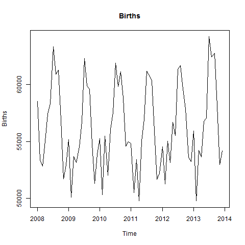

Figure 12

```r
#check correlation of Births
print(cor(TotalAsIs, Births))
```

```
## [1] -0.1190228
```

```r
print(cor(TotalEtelAsIs, Births))
```

```
## [1] -0.1504242
```

The consideration by Chulwalar’s experts was that expecting new parents to try to export more products to pay for the cost of a new child. However, this could not be confirmed.

#### Monthly Satisfaction Index (SI) External Index:

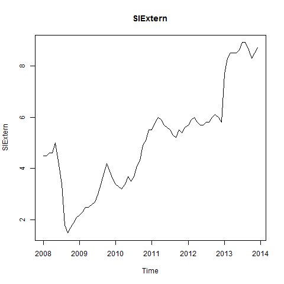

Figure 13

```r
#check correlation of SIExtern
print(cor(TotalAsIs, SIExtern))
```

```
## [1] 0.5883122
```

```r
print(cor(TotalEtelAsIs, SIExtern))
```

```
## [1] 0.2865672
```

This indicator also has a high correlation with Efak exports.

#### Yearly Exports from Urbano:

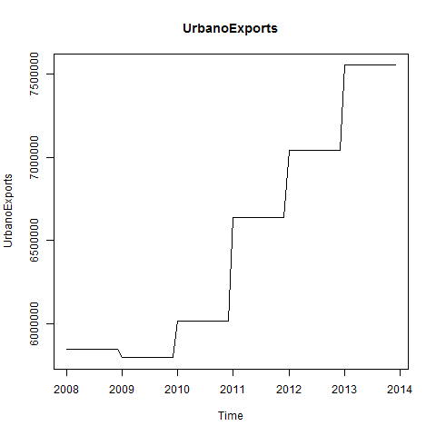

Figure 14

```r
#check correlation of SIExtern
print(cor(TotalAsIs, UrbanoExports))
```

```
## [1] 0.638178
```

```r
print(cor(TotalEtelAsIs, UrbanoExports))
```

```
## [1] 0.3182532
```

This indicator also has a high correlation with Efak exports. The Wuge exports also show a correlation. Unfortunatly it was not possible to find other useful indicators based on exports from Urbano, due to possible informers being very restrictive with information.

#### Yearly Number of Globalisation Party Members in Chulwalar:

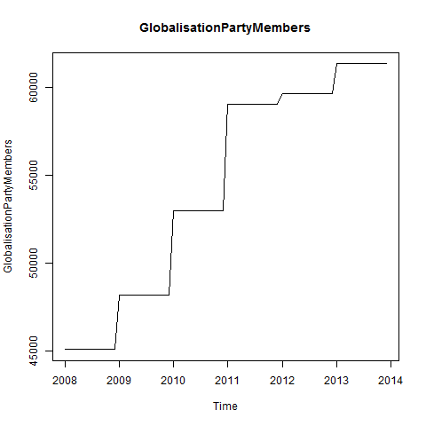

Figure 15

```r
#check correlation of GlobalisationPartyMembers
print(cor(TotalAsIs, GlobalisationPartyMembers))
```

```
## [1] 0.630084
```

```r
print(cor(TotalEtelAsIs, GlobalisationPartyMembers))
```

```
## [1] 0.2994635
```

There is a similar picture here to that of Urbano Exports.It should however be noted that there is a continuos growth here and that the yearly view could lead to the data appearing to correlate, although this could just be due to an increase in trend. Although this could also be true for the Urbano Exports, the trend seems logical due to the Chulwalar’s exports growing in accordance with the Urbano’s Exports.

#### Monthly Average Export Price Index for Chulwalar:

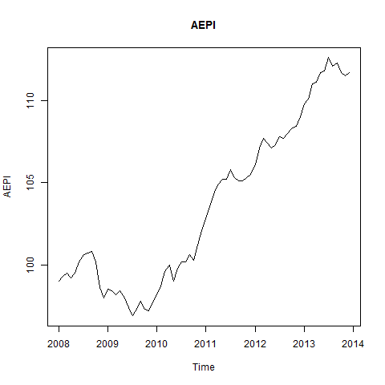

Figure 16

```r
#check correlation of AEPI
print(cor(TotalAsIs, AEPI))
```

```
## [1] 0.625232
```

```r
print(cor(TotalEtelAsIs, AEPI))
```

```
## [1] 0.3035506
```

The continuous growth leads to a good correlation here too. See Above.

#### Monthly Producer Price Index (PPI) for Etel in Chulwalar:

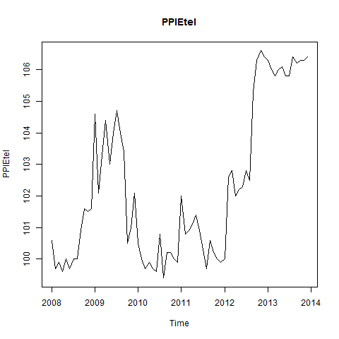

Figure 17

```r
#check correlation of PPIEtel
print(cor(TotalAsIs, PPIEtel))
```

```
## [1] 0.4836129
```

```r
print(cor(TotalEtelAsIs, PPIEtel))
```

```
## [1] 0.3374707
```

This indicator does not give the expected results. It does not show any correlation worth mentioning, not even with the Etel segment.

#### National Holidays:

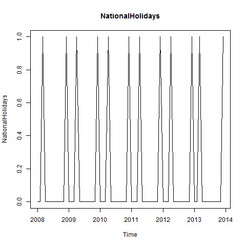

Figure 18

```r
#check correlation of NationalHolidays
print(cor(TotalAsIs, NationalHolidays))
```

```
## [1] -0.007883708
```

```r
print(cor(TotalEtelAsIs, NationalHolidays))
```

```
## [1] -0.01081446
```

#### Chulwalar Index (Total Value of all Companies in Chulwalar):

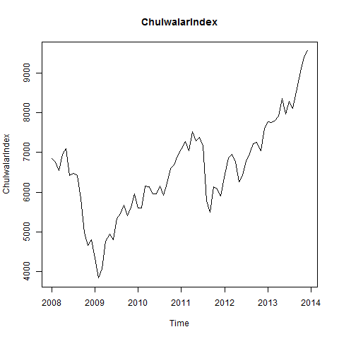

Figure 19

```r
#check correlation of ChulwalarIndex
print(cor(TotalAsIs, ChulwalarIndex))
```

```
## [1] 0.4837017
```

```r
print(cor(TotalEtelAsIs, ChulwalarIndex))
```

```
## [1] 0.2209171
```

No particular findings.

#### Monthly Inflation Rate in Chulwalar:

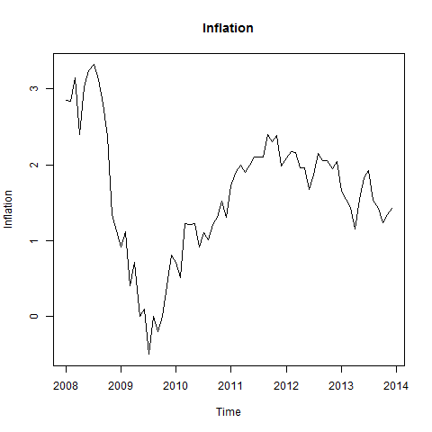

Figure 20

```r
#check correlation of Inflation
print(cor(TotalAsIs, Inflation))
```

```
## [1] 0.002438708
```

```r
print(cor(TotalEtelAsIs, Inflation))
```

```
## [1] -0.08378282
```

No particular findings.

#### Proposed Spending for Independence Day Presents:

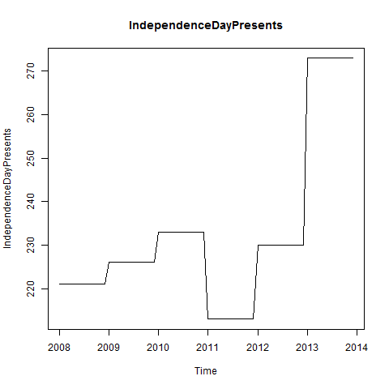

Figure 21

```r
#check correlation of IndependenceDayPresents
cor(TotalAsIs, IndependenceDayPresents)
```

```
## [1] 0.4359522
```

```r
cor(TotalEtelAsIs, IndependenceDayPresents)
```

```
## [1] 0.2872013
```

No particular findings.

#### Influence of National Holidays:

This indicator is an experiment where the influence of National Holidays is extended into the months leading up to the holiday. However later tests show that this indicator is no better for forecasting than the orignial National Holidays indicator.

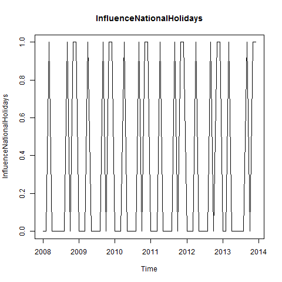

Figure 22

```r
#check correlation of InfluenceNationalHolidays
print(cor(TotalAsIs, InfluenceNationalHolidays))
```

```
## [1] 0.3717463
```

```r
print(cor(TotalEtelAsIs, InfluenceNationalHolidays))
```

```
## [1] 0.4535836
```

```r
#check that the data import has worked
head(CEPIVector)
```

```
## [1] 97.4 97.8 98.3 98.1 98.7 98.9
```

```r
head(SIGovVector)
```

```
## [1] -0.4 -2.9 -2.7  1.7 -1.7 -2.6
```

```r
head(TemperatureVector)
```

```
## [1]  3.6  3.7  4.2  7.6 14.5 16.9
```

```r
head(BirthsVector)
```

```
## [1] 58519 53370 52852 55048 57398 58313
```

```r
head(SIExternVector)
```

```
## [1] 4.5 4.5 4.6 4.6 5.0 4.3
```

```r
head(UrbanoExportsVector)
```

```
## [1] 5850000 5850000 5850000 5850000 5850000 5850000
```

```r
head(GlobalisationPartyMembersVector)
```

```
## [1] 45089 45089 45089 45089 45089 45089
```

```r
head(AEPIVector)
```

```
## [1]  99.0  99.3  99.5  99.2  99.5 100.2
```

```r
head(PPIEtelVector)
```

```
## [1] 100.6  99.7  99.9  99.6 100.0  99.7
```

```r
head(NationalHolidaysVector)
```

```
## [1] 0 0 1 0 0 0
```

```r
head(ChulwalarIndexVector)
```

```
## [1] 6851.75 6748.13 6534.97 6948.82 7096.79 6418.32
```

```r
head(InflationVector)
```

```
## [1] 2.85 2.84 3.15 2.40 3.03 3.24
```

```r
head(IndependenceDayPresentsVector)
```

```
## [1] 221 221 221 221 221 221
```

### 4.2 Correlation of the Indicators with a Time Offset

The External Satisfaction Index indicator is to be offset by one month, to see if the index change makes itself first noticeable on exports in the following months.

[figure not shown]

Figure 23

#### Here December 2013 has been deleted from the time series:

```r
print(cor(TotalAsIsWithoutDec12013, SIExternOffsetByOneMonth))
```

```
## [1] 0.1952995
```

```r
print(cor(TotalEtelAsIsWithoutDec12013, SIExternOffsetByOneMonth))
```

```
## [1] -0.004445279
```

```r
print(summary(TotalAsIsWithoutDec2013_lm))
```

```
##
## Call:
## lm(formula = TotalAsIsWithoutDec12013 ~ SIExternOffsetByOneMonth,
##     data = TotalAsIsWithoutDec12013)
##
## Residuals:
##      Min       1Q   Median       3Q      Max
## -1560602  -560765      246   437927  2142998
##
## Coefficients:
##                          Estimate Std. Error t value Pr(>|t|)
## (Intercept)               3025619     114816  26.352   <2e-16 ***
## SIExternOffsetByOneMonth    15211       9196   1.654    0.103
## ---
## Signif. codes:  0 '***' 0.001 '**' 0.01 '*' 0.05 '.' 0.1 ' ' 1
##
## Residual standard error: 812500 on 69 degrees of freedom
## Multiple R-squared:  0.03814,    Adjusted R-squared:  0.0242
## F-statistic: 2.736 on 1 and 69 DF,  p-value: 0.1026
```

#### Offsett SIGov Indicator by two months:

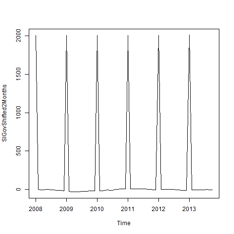

Figure 24

#### Delete November and December 2013 from the time series:

```r
print(cor(TotalAsIsWithoutNovDec2013, SIGovShifted2Months))
```

```
## [1] 0.0446355
```

```r
print(cor(TotalEtelAsIsWithoutNovDec2013, SIGovShifted2Months))
```

```
## [1] 0.1173295
```

```r
print(summary(TotalAsIsWithoutNovDec2013))
```

```
##    Min. 1st Qu.  Median    Mean 3rd Qu.    Max.
## 1458000 2353000 2901000 2897000 3329000 5108000
```

The correlation of the indicators has not really been improved by the offsets, so we will not continue with this approach.

### 4.3 Correlation of the Indicators with Each Other

In order to test which indicators could be used in a model with eachother, we need to look at the correlation of the indicators with eachother. All thirteen indicators will be compared with eachother in a correlation coefficient matrix. First of all it is necessary to summarise all indicators in a matrix.  
####Establish the standardised data matrix:

```r
print(head(IndicatorsmatrixStandardised))
```

```
##      CEPIVector SIGovVector TemperatureVector BirthsVector SIGovVector
## [1,] -1.5292232   0.6019786        -0.8015830    0.6357158   0.6019786
## [2,] -1.3821236   0.3638332        -0.7867017   -0.7548522   0.3638332
## [3,] -1.1982491   0.3828849        -0.7122954   -0.8947462   0.3828849
## [4,] -1.2717989   0.8020208        -0.2063327   -0.3016821   0.8020208
## [5,] -1.0511494   0.4781430         0.8204739    0.3329722   0.4781430
## [6,] -0.9775996   0.3924107         1.1776240    0.5800823   0.3924107
##      UrbanoExportsVector GlobalisationPartyMembersVector AEPIVector
## [1,]          -0.9637871                       -1.507017 -0.9164668
## [2,]          -0.9637871                       -1.507017 -0.8561509
## [3,]          -0.9637871                       -1.507017 -0.8159403
## [4,]          -0.9637871                       -1.507017 -0.8762562
## [5,]          -0.9637871                       -1.507017 -0.8159403
## [6,]          -0.9637871                       -1.507017 -0.6752032
##         PPIEtel NationalHolidaysVector ChulwalarIndexVector
## [1,] -0.6937760             -0.4440971           0.25840362
## [2,] -1.0625757             -0.4440971           0.17119839
## [3,] -0.9806202              2.2204854          -0.00819425
## [4,] -1.1035535             -0.4440971           0.34009645
## [5,] -0.9396425             -0.4440971           0.46462605
## [6,] -1.0625757             -0.4440971          -0.10636535
##      InflationVector IndependenceDayPresentsVector
## [1,]       1.4687496                    -0.6048427
## [2,]       1.4569353                    -0.6048427
## [3,]       1.8231792                    -0.6048427
## [4,]       0.9371052                    -0.6048427
## [5,]       1.6814073                    -0.6048427
## [6,]       1.9295080                    -0.6048427
```

#### The dimensions of the matrix are determined by the number of indicators:

```r
print(NumberOfIndicators)
```

```
## [1] 72
```

#### Produce the IndicatorsCorrelationCoefficientMatrix.

```r
print(IndicatorsCorrelationCoefficientMatrix)
```

```
##                                 CEPIVector SIGovVector TemperatureVector
## CEPIVector                      1.00000000  0.38443508       0.061196862
## SIGovVector                     0.38443508  1.00000000       0.088109231
## TemperatureVector               0.06119686  0.08810923       1.000000000
## BirthsVector                    0.08872676  0.12753378       0.744270853
## SIGovVector                     0.38443508  1.00000000       0.088109231
## UrbanoExportsVector             0.97660022  0.40700264      -0.001244458
## GlobalisationPartyMembersVector 0.91557949  0.49433954      -0.009695828
## AEPIVector                      0.97697428  0.45955807       0.055196145
## PPIEtel                         0.65446147 -0.23602751      -0.013959906
## NationalHolidaysVector          0.04830482 -0.02025819      -0.316148237
## ChulwalarIndexVector            0.76208613  0.63652935       0.036317166
## InflationVector                 0.16379793  0.55866085       0.054966975
## IndependenceDayPresentsVector   0.64887003  0.03237405      -0.040110690
##                                 BirthsVector SIGovVector
## CEPIVector                        0.08872676  0.38443508
## SIGovVector                       0.12753378  1.00000000
## TemperatureVector                 0.74427085  0.08810923
## BirthsVector                      1.00000000  0.12753378
## SIGovVector                       0.12753378  1.00000000
## UrbanoExportsVector               0.03139251  0.40700264
## GlobalisationPartyMembersVector  -0.01768274  0.49433954
## AEPIVector                        0.09673808  0.45955807
## PPIEtel                           0.05960084 -0.23602751
## NationalHolidaysVector           -0.37785553 -0.02025819
## ChulwalarIndexVector              0.11795545  0.63652935
## InflationVector                   0.11231574  0.55866085
## IndependenceDayPresentsVector     0.10063892  0.03237405
##                                 UrbanoExportsVector
## CEPIVector                             9.766002e-01
## SIGovVector                            4.070026e-01
## TemperatureVector                     -1.244458e-03
## BirthsVector                           3.139251e-02
## SIGovVector                            4.070026e-01
## UrbanoExportsVector                    1.000000e+00
## GlobalisationPartyMembersVector        9.121013e-01
## AEPIVector                             9.827920e-01
## PPIEtel                                6.521194e-01
## NationalHolidaysVector                -1.876433e-17
## ChulwalarIndexVector                   7.856783e-01
```

[output cut: 43 more lines]

```
## IndependenceDayPresentsVector             0.62615921    -0.185842679
##                                 IndependenceDayPresentsVector
## CEPIVector                                         0.64887003
## SIGovVector                                        0.03237405
## TemperatureVector                                 -0.04011069
## BirthsVector                                       0.10063892
## SIGovVector                                        0.03237405
## UrbanoExportsVector                                0.66999963
## GlobalisationPartyMembersVector                    0.46063633
## AEPIVector                                         0.64313387
## PPIEtel                                            0.71474813
## NationalHolidaysVector                             0.00000000
## ChulwalarIndexVector                               0.62615921
## InflationVector                                   -0.18584268
## IndependenceDayPresentsVector                      1.00000000
```

## 5.0 Development of Forecasting Models

With help of the tslm function, we will produce a model based on the time series. Possible inputs could be Trend and Seasonality as well as the time series of the indicators.

### 5.1 ModelWithAlllIndicators and with Each Indicator Individually

```r
source("Scripts/developModels.r")
```

#### All Indiators in one model:

```r
print(summary(ModelWithAlllIndicators))
```

```
##
## Call:
## tslm(formula = TotalAsIs ~ trend + season + CEPI + SIGov + Temperature +
##     Births + SIExtern + UrbanoExports + GlobalisationPartyMembers +
##     AEPI + PPIEtel + NationalHolidays + ChulwalarIndex + Inflation +
##     IndependenceDayPresents)
##
## Residuals:
##     Min      1Q  Median      3Q     Max
## -458389 -119426    1119  165463  342741
##
## Coefficients:
##                             Estimate Std. Error t value Pr(>|t|)
## (Intercept)               -8.982e+05  2.301e+07  -0.039  0.96904
## trend                      3.176e+03  3.849e+04   0.083  0.93458
## season2                    3.146e+05  2.678e+05   1.175  0.24624
## season3                    5.172e+05  2.649e+05   1.953  0.05695 .
## season4                    2.972e+05  3.413e+05   0.871  0.38836
## season5                   -7.277e+04  3.661e+05  -0.199  0.84333
## season6                   -2.597e+05  4.199e+05  -0.618  0.53932
## season7                   -7.550e+05  5.225e+05  -1.445  0.15525
## season8                   -2.869e+05  4.990e+05  -0.575  0.56809
## season9                    1.066e+06  4.225e+05   2.523  0.01517 *
## season10                   8.033e+05  3.352e+05   2.396  0.02068 *
## season11                   1.226e+06  3.555e+05   3.449  0.00122 **
## season12                   9.734e+05  3.645e+05   2.670  0.01044 *
## CEPI                      -3.551e+04  2.516e+05  -0.141  0.88838
## SIGov                     -1.506e+04  9.150e+03  -1.646  0.10657
## Temperature               -3.108e+04  2.069e+04  -1.502  0.14003
## Births                     8.045e+01  3.894e+01   2.066  0.04448 *
## SIExtern                   3.706e+04  5.872e+04   0.631  0.53109
## UrbanoExports              5.323e-01  5.675e-01   0.938  0.35317
## GlobalisationPartyMembers  7.324e+01  6.583e+01   1.113  0.27163
## AEPI                      -6.003e+04  7.476e+04  -0.803  0.42612
## PPIEtel                    7.799e+03  3.622e+04   0.215  0.83048
## NationalHolidays          -3.192e+05  1.718e+05  -1.858  0.06963 .
## ChulwalarIndex             6.102e+01  7.545e+01   0.809  0.42284
## Inflation                  7.058e+04  1.555e+05   0.454  0.65213
## IndependenceDayPresents    4.211e+01  6.187e+03   0.007  0.99460
## ---
## Signif. codes:  0 '***' 0.001 '**' 0.01 '*' 0.05 '.' 0.1 ' ' 1
##
## Residual standard error: 249400 on 46 degrees of freedom
## Multiple R-squared:  0.9421, Adjusted R-squared:  0.9106
## F-statistic: 29.94 on 25 and 46 DF,  p-value: < 2.2e-16
```

```r
# Adjusted R²: 0.9106
```

#### CEPI:

```r
summary(ModelWithCEPI)
```

```
##
## Call:
## tslm(formula = TotalAsIs ~ trend + season + CEPI)
##
## Residuals:
##     Min      1Q  Median      3Q     Max
## -670684 -142117    7024  168664  495366
##
## Coefficients:
##             Estimate Std. Error t value Pr(>|t|)
## (Intercept) -2946424    5153463  -0.572 0.569710
## trend          19698       6926   2.844 0.006145 **
## season2      -153665     153683  -1.000 0.321523
## season3         8677     156732   0.055 0.956039
## season4      -634082     154130  -4.114 0.000124 ***
## season5      -648875     154240  -4.207 9.09e-05 ***
## season6      -906108     153943  -5.886 2.10e-07 ***
## season7     -1112258     155872  -7.136 1.73e-09 ***
## season8      -755527     155490  -4.859 9.34e-06 ***
## season9       683382     154129   4.434 4.18e-05 ***
## season10      287071     153168   1.874 0.065940 .
## season11      465878     152885   3.047 0.003474 **
## season12       50523     154712   0.327 0.745176
## CEPI           53135      53376   0.995 0.323636
## ---
## Signif. codes:  0 '***' 0.001 '**' 0.01 '*' 0.05 '.' 0.1 ' ' 1
##
## Residual standard error: 263300 on 58 degrees of freedom
## Multiple R-squared:  0.9187, Adjusted R-squared:  0.9004
## F-statistic: 50.39 on 13 and 58 DF,  p-value: < 2.2e-16
```

```r
# Adjusted R²: 0.9004
```

##### SIGov:

The Satisfaction Index (gov) hardly changes the function of the model.

```r
summary(ModelWithSIGov)
```

```
##
## Call:
## tslm(formula = TotalAsIs ~ trend + season + SIGov)
##
## Residuals:
##     Min      1Q  Median      3Q     Max
## -697126 -157160   22782  161382  486711
##
## Coefficients:
##             Estimate Std. Error t value Pr(>|t|)
## (Intercept)  2154993     126151  17.083  < 2e-16 ***
## trend          26826       1656  16.196  < 2e-16 ***
## season2      -133003     152843  -0.870 0.387782
## season3        44751     152866   0.293 0.770763
## season4      -606128     152952  -3.963 0.000205 ***
## season5      -622634     152935  -4.071 0.000143 ***
## season6      -881666     153013  -5.762 3.35e-07 ***
## season7     -1075681     153183  -7.022 2.69e-09 ***
## season8      -726089     153194  -4.740 1.43e-05 ***
## season9       705690     153291   4.604 2.31e-05 ***
## season10      297924     153457   1.941 0.057071 .
## season11      468770     153659   3.051 0.003439 **
## season12       68494     153977   0.445 0.658095
## SIGov          -2003       3274  -0.612 0.543174
## ---
## Signif. codes:  0 '***' 0.001 '**' 0.01 '*' 0.05 '.' 0.1 ' ' 1
##
## Residual standard error: 264700 on 58 degrees of freedom
## Multiple R-squared:  0.9178, Adjusted R-squared:  0.8994
## F-statistic: 49.81 on 13 and 58 DF,  p-value: < 2.2e-16
```

```r
# Adjusted R²: 0.8994
```

#### Temperature:

```r
summary(ModelWithTemperature)
```

```
##
## Call:
## tslm(formula = TotalAsIs ~ trend + season + Temperature)
##
## Residuals:
##     Min      1Q  Median      3Q     Max
## -706803 -154965   23511  160215  483373
##
## Coefficients:
##             Estimate Std. Error t value Pr(>|t|)
## (Intercept)  2185999     118102  18.509  < 2e-16 ***
## trend          26367       1526  17.278  < 2e-16 ***
## season2      -130163     152875  -0.851  0.39803
## season3        91513     171443   0.534  0.59553
## season4      -504879     236159  -2.138  0.03675 *
## season5      -476774     296010  -1.611  0.11268
## season6      -703539     345717  -2.035  0.04643 *
## season7      -873818     386156  -2.263  0.02740 *
## season8      -524053     378812  -1.383  0.17184
## season9       858772     305542   2.811  0.00673 **
## season10      401142     232466   1.726  0.08974 .
## season11      530742     183985   2.885  0.00549 **
## season12       85552     155077   0.552  0.58329
## Temperature   -11344      19587  -0.579  0.56473
## ---
## Signif. codes:  0 '***' 0.001 '**' 0.01 '*' 0.05 '.' 0.1 ' ' 1
##
## Residual standard error: 264800 on 58 degrees of freedom
## Multiple R-squared:  0.9177, Adjusted R-squared:  0.8993
## F-statistic: 49.78 on 13 and 58 DF,  p-value: < 2.2e-16
```

```r
# Adjusted R²: 0.8993
```

#### Births:

```r
summary(ModelWithBirths)
```

```
##
## Call:
## tslm(formula = TotalAsIs ~ trend + season + Births)
##
## Residuals:
##     Min      1Q  Median      3Q     Max
## -648252 -106586   23124  166173  443675
##
## Coefficients:
##               Estimate Std. Error t value Pr(>|t|)
## (Intercept) -1.485e+06  1.452e+06  -1.023 0.310779
## trend        2.633e+04  1.449e+03  18.163  < 2e-16 ***
## season2      1.856e+05  1.918e+05   0.968 0.337199
## season3      1.510e+05  1.512e+05   0.998 0.322286
## season4     -4.181e+05  1.639e+05  -2.551 0.013402 *
## season5     -6.484e+05  1.459e+05  -4.444 4.04e-05 ***
## season6     -9.698e+05  1.496e+05  -6.482 2.16e-08 ***
## season7     -1.518e+06  2.265e+05  -6.704 9.20e-09 ***
## season8     -1.068e+06  1.992e+05  -5.364 1.48e-06 ***
## season9      3.721e+05  1.966e+05   1.893 0.063345 .
## season10     2.114e+05  1.502e+05   1.407 0.164622
## season11     6.744e+05  1.666e+05   4.049 0.000155 ***
## season12     2.147e+05  1.565e+05   1.372 0.175458
## Births       6.589e+01  2.601e+01   2.533 0.014026 *
## ---
## Signif. codes:  0 '***' 0.001 '**' 0.01 '*' 0.05 '.' 0.1 ' ' 1
##
## Residual standard error: 251900 on 58 degrees of freedom
## Multiple R-squared:  0.9255, Adjusted R-squared:  0.9088
## F-statistic: 55.43 on 13 and 58 DF,  p-value: < 2.2e-16
```

```r
# Adjusted R²: 0.9088
```

#### SIExtern:

```r
summary(ModelWithSIExtern)
```

```
##
## Call:
## tslm(formula = TotalAsIs ~ trend + season + SIExtern)
##
## Residuals:
##     Min      1Q  Median      3Q     Max
## -667444 -154044   -5891  162628  473612
##
## Coefficients:
##             Estimate Std. Error t value Pr(>|t|)
## (Intercept)  2124425     137869  15.409  < 2e-16 ***
## trend          24163       3191   7.572 3.20e-10 ***
## season2      -133767     152487  -0.877 0.383979
## season3        43156     152535   0.283 0.778243
## season4      -609825     152516  -3.998 0.000183 ***
## season5      -624208     152569  -4.091 0.000134 ***
## season6      -877941     152767  -5.747 3.55e-07 ***
## season7     -1071287     153027  -7.001 2.92e-09 ***
## season8      -710173     153873  -4.615 2.22e-05 ***
## season9       722059     154265   4.681 1.76e-05 ***
## season10      312879     153885   2.033 0.046617 *
## season11      486780     154278   3.155 0.002542 **
## season12       88661     154442   0.574 0.568139
## SIExtern       26522      32881   0.807 0.423187
## ---
## Signif. codes:  0 '***' 0.001 '**' 0.01 '*' 0.05 '.' 0.1 ' ' 1
##
## Residual standard error: 264000 on 58 degrees of freedom
## Multiple R-squared:  0.9182, Adjusted R-squared:  0.8998
## F-statistic: 50.07 on 13 and 58 DF,  p-value: < 2.2e-16
```

```r
# Adjusted R²: 0.8998
```

#### UrbanoExports:

Indicator with adjusted R² shows a better result than the reference model (ModelWithTrendAndSeasonalityOnly). The individual months are also very significant.

```r
summary(ModelWithTotalUrbanoExports)
```

```
##
## Call:
## tslm(formula = TotalAsIs ~ trend + season + UrbanoExports)
##
## Residuals:
##     Min      1Q  Median      3Q     Max
## -651323 -145654    7297  172919  469753
##
## Coefficients:
##                 Estimate Std. Error t value Pr(>|t|)
## (Intercept)    1.232e+06  9.485e+05   1.299 0.199178
## trend          2.118e+04  5.414e+03   3.912 0.000243 ***
## season2       -1.259e+05  1.521e+05  -0.828 0.411030
## season3        5.708e+04  1.524e+05   0.375 0.709261
## season4       -5.934e+05  1.528e+05  -3.882 0.000267 ***
## season5       -6.025e+05  1.535e+05  -3.925 0.000232 ***
## season6       -8.568e+05  1.544e+05  -5.551 7.40e-07 ***
## season7       -1.048e+06  1.554e+05  -6.741 7.96e-09 ***
## season8       -6.879e+05  1.566e+05  -4.392 4.82e-05 ***
## season9        7.477e+05  1.580e+05   4.732 1.47e-05 ***
## season10       3.473e+05  1.596e+05   2.176 0.033640 *
## season11       5.246e+05  1.613e+05   3.252 0.001913 **
## season12       1.317e+05  1.632e+05   0.807 0.423118
## UrbanoExports  1.717e-01  1.700e-01   1.010 0.316698
## ---
## Signif. codes:  0 '***' 0.001 '**' 0.01 '*' 0.05 '.' 0.1 ' ' 1
##
## Residual standard error: 263200 on 58 degrees of freedom
## Multiple R-squared:  0.9187, Adjusted R-squared:  0.9005
## F-statistic: 50.41 on 13 and 58 DF,  p-value: < 2.2e-16
```

```r
# Adjusted R²: 0.9005
```

#### GlobalisationPartyMembers:

```r
summary(ModelWithGlobalisationPartyMembers)
```

```
##
## Call:
## tslm(formula = TotalAsIs ~ trend + season + GlobalisationPartyMembers)
##
## Residuals:
##     Min      1Q  Median      3Q     Max
## -696019 -161848   22345  172443  478347
##
## Coefficients:
##                             Estimate Std. Error t value Pr(>|t|)
## (Intercept)                2.629e+06  9.653e+05   2.724 0.008517 **
## trend                      2.928e+04  6.311e+03   4.640 2.04e-05 ***
## season2                   -1.340e+05  1.531e+05  -0.875 0.385097
## season3                    4.087e+04  1.535e+05   0.266 0.791010
## season4                   -6.177e+05  1.542e+05  -4.006 0.000178 ***
## season5                   -6.350e+05  1.551e+05  -4.094 0.000133 ***
## season6                   -8.973e+05  1.562e+05  -5.744 3.59e-07 ***
## season7                   -1.096e+06  1.576e+05  -6.955 3.49e-09 ***
## season8                   -7.447e+05  1.593e+05  -4.676 1.79e-05 ***
## season9                    6.829e+05  1.611e+05   4.238 8.18e-05 ***
## season10                   2.743e+05  1.632e+05   1.681 0.098191 .
## season11                   4.435e+05  1.655e+05   2.680 0.009573 **
## season12                   4.252e+04  1.680e+05   0.253 0.801132
## GlobalisationPartyMembers -9.840e+00  2.111e+01  -0.466 0.642806
## ---
## Signif. codes:  0 '***' 0.001 '**' 0.01 '*' 0.05 '.' 0.1 ' ' 1
##
## Residual standard error: 265000 on 58 degrees of freedom
## Multiple R-squared:  0.9176, Adjusted R-squared:  0.8991
## F-statistic: 49.67 on 13 and 58 DF,  p-value: < 2.2e-16
```

```r
# Adjusted R²: 0.8991
```

#### AEPI:

```r
summary(ModelWithAEPI)
```

```
##
## Call:
## tslm(formula = TotalAsIs ~ trend + season + AEPI)
##
## Residuals:
##     Min      1Q  Median      3Q     Max
## -668980 -141696    1689  169009  482621
##
## Coefficients:
##             Estimate Std. Error t value Pr(>|t|)
## (Intercept)   839421    1642691   0.511 0.611288
## trend          23291       4116   5.658 4.95e-07 ***
## season2      -134830     152491  -0.884 0.380247
## season3        38792     152745   0.254 0.800419
## season4      -615165     152666  -4.029 0.000165 ***
## season5      -625294     152554  -4.099 0.000131 ***
## season6      -884504     152617  -5.796 2.95e-07 ***
## season7     -1082577     152748  -7.087 2.09e-09 ***
## season8      -723603     152794  -4.736 1.45e-05 ***
## season9       706895     152908   4.623 2.16e-05 ***
## season10      308319     153364   2.010 0.049049 *
## season11      485176     154001   3.150 0.002578 **
## season12       85919     154027   0.558 0.579115
## AEPI           14065      17159   0.820 0.415759
## ---
## Signif. codes:  0 '***' 0.001 '**' 0.01 '*' 0.05 '.' 0.1 ' ' 1
##
## Residual standard error: 264000 on 58 degrees of freedom
## Multiple R-squared:  0.9182, Adjusted R-squared:  0.8999
## F-statistic: 50.09 on 13 and 58 DF,  p-value: < 2.2e-16
```

```r
# Adjusted R²: 0.8999
```

#### PPIEtel:

```r
summary(ModelWithPPIEtel)
```

```
##
## Call:
## tslm(formula = TotalAsIs ~ trend + season + PPIEtel)
##
## Residuals:
##     Min      1Q  Median      3Q     Max
## -670282 -185589   19856  172554  468929
##
## Coefficients:
##             Estimate Std. Error t value Pr(>|t|)
## (Intercept)   593668    1640506   0.362 0.718756
## trend          25282       1919  13.172  < 2e-16 ***
## season2      -122617     152330  -0.805 0.424141
## season3        53107     152246   0.349 0.728486
## season4      -603022     152264  -3.960 0.000207 ***
## season5      -614727     152459  -4.032 0.000163 ***
## season6      -872851     152619  -5.719 3.94e-07 ***
## season7     -1073314     152456  -7.040 2.51e-09 ***
## season8      -711389     153051  -4.648 1.98e-05 ***
## season9       707996     152568   4.641 2.03e-05 ***
## season10      307412     152867   2.011 0.048984 *
## season11      479843     153028   3.136 0.002692 **
## season12       80433     153124   0.525 0.601390
## PPIEtel        15872      16347   0.971 0.335606
## ---
## Signif. codes:  0 '***' 0.001 '**' 0.01 '*' 0.05 '.' 0.1 ' ' 1
##
## Residual standard error: 263400 on 58 degrees of freedom
## Multiple R-squared:  0.9186, Adjusted R-squared:  0.9003
## F-statistic: 50.34 on 13 and 58 DF,  p-value: < 2.2e-16
```

```r
# Adjusted R²: 0.9003
```

#### NationalHolidays:

Indicator with the best adjusted R². The months remain very significant and the indicator itself has a p-value of 0,00636**

```r
summary(ModelWithNationalHolidays)
```

```
##
## Call:
## tslm(formula = TotalAsIs ~ trend + season + NationalHolidays)
##
## Residuals:
##     Min      1Q  Median      3Q     Max
## -555545 -153976       4  150487  404837
##
## Coefficients:
##                  Estimate Std. Error t value Pr(>|t|)
## (Intercept)       2182435     110867  19.685  < 2e-16 ***
## trend               26427       1431  18.465  < 2e-16 ***
## season2           -131168     143696  -0.913  0.36512
## season3            190430     152432   1.249  0.21658
## season4           -321411     176034  -1.826  0.07302 .
## season5           -623539     143803  -4.336 5.86e-05 ***
## season6           -883072     143867  -6.138 8.06e-08 ***
## season7          -1079124     143945  -7.497 4.29e-10 ***
## season8           -724693     144037  -5.031 5.02e-06 ***
## season9            705716     144144   4.896 8.18e-06 ***
## season10           300019     144265   2.080  0.04199 *
## season11           472099     144400   3.269  0.00182 **
## season12           505461     210051   2.406  0.01932 *
## NationalHolidays  -431536     152405  -2.832  0.00636 **
## ---
## Signif. codes:  0 '***' 0.001 '**' 0.01 '*' 0.05 '.' 0.1 ' ' 1
##
## Residual standard error: 248900 on 58 degrees of freedom
## Multiple R-squared:  0.9273, Adjusted R-squared:  0.911
## F-statistic: 56.92 on 13 and 58 DF,  p-value: < 2.2e-16
```

```r
# Adjusted R²: 0.9110
```

#### ChulwalarIndex:

```r
summary(ModelWithChulwalarIndex)
```

```
##
## Call:
## tslm(formula = TotalAsIs ~ trend + season + ChulwalarIndex)
##
## Residuals:
##     Min      1Q  Median      3Q     Max
## -689635 -153608    9444  166039  495113
##
## Coefficients:
##                  Estimate Std. Error t value Pr(>|t|)
## (Intercept)     2.013e+06  2.262e+05   8.898 1.96e-12 ***
## trend           2.506e+04  2.176e+03  11.515  < 2e-16 ***
## season2        -1.295e+05  1.523e+05  -0.850 0.398630
## season3         4.684e+04  1.523e+05   0.308 0.759534
## season4        -6.157e+05  1.525e+05  -4.036 0.000161 ***
## season5        -6.281e+05  1.525e+05  -4.119 0.000122 ***
## season6        -8.809e+05  1.525e+05  -5.776 3.18e-07 ***
## season7        -1.082e+06  1.526e+05  -7.092 2.05e-09 ***
## season8        -7.182e+05  1.528e+05  -4.699 1.65e-05 ***
## season9         7.115e+05  1.529e+05   4.653 1.95e-05 ***
## season10        3.049e+05  1.530e+05   1.993 0.050965 .
## season11        4.779e+05  1.532e+05   3.120 0.002817 **
## season12        7.433e+04  1.532e+05   0.485 0.629364
## ChulwalarIndex  3.339e+01  3.805e+01   0.878 0.383723
## ---
## Signif. codes:  0 '***' 0.001 '**' 0.01 '*' 0.05 '.' 0.1 ' ' 1
##
## Residual standard error: 263800 on 58 degrees of freedom
## Multiple R-squared:  0.9184, Adjusted R-squared:  0.9001
## F-statistic: 50.18 on 13 and 58 DF,  p-value: < 2.2e-16
```

```r
# Adjusted R²: 0.9001
```

#### Inflation:

```r
summary(ModelWithInflation)
```

```
##
## Call:
## tslm(formula = TotalAsIs ~ trend + season + Inflation)
##
## Residuals:
##     Min      1Q  Median      3Q     Max
## -694867 -148205    9248  156635  501218
##
## Coefficients:
##             Estimate Std. Error t value Pr(>|t|)
## (Intercept)  2160745     132862  16.263  < 2e-16 ***
## trend          26414       1526  17.313  < 2e-16 ***
## season2      -131511     153141  -0.859 0.394009
## season3        45633     153184   0.298 0.766848
## season4      -607707     153249  -3.966 0.000204 ***
## season5      -623065     153258  -4.065 0.000146 ***
## season6      -882807     153322  -5.758 3.41e-07 ***
## season7     -1078758     153407  -7.032 2.59e-09 ***
## season8      -724536     153503  -4.720 1.53e-05 ***
## season9       706375     153627   4.598 2.36e-05 ***
## season10      301603     153808   1.961 0.054698 .
## season11      474428     154026   3.080 0.003160 **
## season12       76824     154261   0.498 0.620359
## Inflation      13335      37358   0.357 0.722422
## ---
## Signif. codes:  0 '***' 0.001 '**' 0.01 '*' 0.05 '.' 0.1 ' ' 1
##
## Residual standard error: 265200 on 58 degrees of freedom
## Multiple R-squared:  0.9174, Adjusted R-squared:  0.8989
## F-statistic: 49.58 on 13 and 58 DF,  p-value: < 2.2e-16
```

```r
# Adjusted R²: 0.8989
```

#### IndependenceDayPresents:

```r
summary(ModelWithIndependenceDayPresents)
```

```
##
## Call:
## tslm(formula = TotalAsIs ~ trend + season + IndependenceDayPresents)
##
## Residuals:
##     Min      1Q  Median      3Q     Max
## -704113 -161955   23265  169241  468613
##
## Coefficients:
##                         Estimate Std. Error t value Pr(>|t|)
## (Intercept)              1925395     469903   4.097 0.000131 ***
## trend                      25706       1986  12.944  < 2e-16 ***
## season2                  -130448     152891  -0.853 0.397053
## season3                    48026     152930   0.314 0.754620
## season4                  -606940     152994  -3.967 0.000203 ***
## season5                  -620657     153084  -4.054 0.000152 ***
## season6                  -879470     153200  -5.741 3.63e-07 ***
## season7                 -1074801     153342  -7.009 2.83e-09 ***
## season8                  -719650     153509  -4.688 1.72e-05 ***
## season9                   711480     153702   4.629 2.12e-05 ***
## season10                  306503     153919   1.991 0.051162 .
## season11                  479303     154163   3.109 0.002907 **
## season12                   81850     154431   0.530 0.598127
## IndependenceDayPresents     1201       2125   0.565 0.574184
## ---
## Signif. codes:  0 '***' 0.001 '**' 0.01 '*' 0.05 '.' 0.1 ' ' 1
##
## Residual standard error: 264800 on 58 degrees of freedom
## Multiple R-squared:  0.9177, Adjusted R-squared:  0.8993
## F-statistic: 49.76 on 13 and 58 DF,  p-value: < 2.2e-16
```

```r
# Adjusted R²: 0.8993
```

#### InfluenceNationalHolidays:

Indicator with the best adjusted R². The months remain very significant and the indicator itself has a p-value of 0,00636**

```r
summary(ModelWithInfluenceNationalHolidays)
```

```
##
## Call:
## tslm(formula = TotalAsIs ~ trend + season + InfluenceNationalHolidays)
##
## Residuals:
##     Min      1Q  Median      3Q     Max
## -555545 -153976       4  150487  404837
##
## Coefficients:
##                           Estimate Std. Error t value Pr(>|t|)
## (Intercept)                2182435     110867  19.685  < 2e-16 ***
## trend                        26427       1431  18.465  < 2e-16 ***
## season2                    -131168     143696  -0.913  0.36512
## season3                     190430     152432   1.249  0.21658
## season4                    -321411     176034  -1.826  0.07302 .
## season5                    -623539     143803  -4.336 5.86e-05 ***
## season6                    -883072     143867  -6.138 8.06e-08 ***
## season7                   -1079124     143945  -7.497 4.29e-10 ***
## season8                    -724693     144037  -5.031 5.02e-06 ***
## season9                    1137252     209773   5.421 1.20e-06 ***
## season10                    300019     144265   2.080  0.04199 *
## season11                    903635     209949   4.304 6.53e-05 ***
## season12                    505461     210051   2.406  0.01932 *
## InfluenceNationalHolidays  -431536     152405  -2.832  0.00636 **
## ---
## Signif. codes:  0 '***' 0.001 '**' 0.01 '*' 0.05 '.' 0.1 ' ' 1
##
## Residual standard error: 248900 on 58 degrees of freedom
## Multiple R-squared:  0.9273, Adjusted R-squared:  0.911
## F-statistic: 56.92 on 13 and 58 DF,  p-value: < 2.2e-16
```

```r
# Adjusted R²: 0.9110
```

### 5.2 Models

#### ModelWithHighCorrelatingIndicators:

In this model only the indicators that correlate well with eachother have been used.

```r
summary(ModelWithHighCorrelatingIndicators)
```

```
##
## Call:
## tslm(formula = TotalAsIs ~ trend + season + CEPI + SIExtern +
##     UrbanoExports + GlobalisationPartyMembers + AEPI)
##
## Residuals:
##     Min      1Q  Median      3Q     Max
## -651383 -159842   14275  171424  489393
##
## Coefficients:
##                             Estimate Std. Error t value Pr(>|t|)
## (Intercept)               -4.625e+06  1.240e+07  -0.373  0.71054
## trend                      1.446e+04  1.650e+04   0.876  0.38477
## season2                   -1.584e+05  1.724e+05  -0.919  0.36213
## season3                    7.086e+03  1.984e+05   0.036  0.97164
## season4                   -6.221e+05  1.862e+05  -3.341  0.00152 **
## season5                   -6.417e+05  1.944e+05  -3.302  0.00171 **
## season6                   -8.872e+05  1.983e+05  -4.473 4.01e-05 ***
## season7                   -1.088e+06  2.218e+05  -4.904 8.99e-06 ***
## season8                   -7.287e+05  2.260e+05  -3.225  0.00214 **
## season9                    7.236e+05  2.261e+05   3.201  0.00230 **
## season10                   3.199e+05  2.231e+05   1.434  0.15741
## season11                   4.997e+05  2.246e+05   2.225  0.03027 *
## season12                   7.986e+04  2.585e+05   0.309  0.75853
## CEPI                       9.245e+04  1.672e+05   0.553  0.58252
## SIExtern                   2.378e+04  4.559e+04   0.522  0.60401
## UrbanoExports              1.504e-01  5.104e-01   0.295  0.76934
## GlobalisationPartyMembers  3.463e+00  2.546e+01   0.136  0.89233
## AEPI                      -3.307e+04  5.992e+04  -0.552  0.58327
## ---
## Signif. codes:  0 '***' 0.001 '**' 0.01 '*' 0.05 '.' 0.1 ' ' 1
##
## Residual standard error: 271600 on 54 degrees of freedom
## Multiple R-squared:  0.9194, Adjusted R-squared:  0.8941
## F-statistic: 36.25 on 17 and 54 DF,  p-value: < 2.2e-16
```

```r
# Adjusted R²: 0.8941
```

It can be seen that the addition of these indicators causes the seasonality to be weakened. The individual indicators are not very significant either. Is this a multicollinearity effect? Or is it just because we have chose irrelevant indicators? An experimental idea comes from the next section:

#### ModelWithLowCorrelatingIndicators:

In this model only the indicators that hardly correlate at all with eachother have been used.

```r
summary(ModelWithLowCorrelatingIndicators)
```

```
##
## Call:
## tslm(formula = TotalAsIs ~ trend + season + NationalHolidays +
##     UrbanoExports + GlobalisationPartyMembers)
##
## Residuals:
##     Min      1Q  Median      3Q     Max
## -508755 -122676    7119  173089  403964
##
## Coefficients:
##                             Estimate Std. Error t value Pr(>|t|)
## (Intercept)                1.467e+06  1.517e+06   0.967 0.337647
## trend                      2.264e+04  9.148e+03   2.474 0.016399 *
## season2                   -1.274e+05  1.450e+05  -0.878 0.383528
## season3                    1.980e+05  1.546e+05   1.281 0.205562
## season4                   -3.100e+05  1.794e+05  -1.728 0.089424 .
## season5                   -6.084e+05  1.493e+05  -4.075 0.000146 ***
## season6                   -8.641e+05  1.518e+05  -5.693 4.78e-07 ***
## season7                   -1.056e+06  1.548e+05  -6.824 6.75e-09 ***
## season8                   -6.982e+05  1.583e+05  -4.411 4.72e-05 ***
## season9                    7.360e+05  1.622e+05   4.538 3.05e-05 ***
## season10                   3.341e+05  1.665e+05   2.007 0.049635 *
## season11                   5.100e+05  1.712e+05   2.979 0.004276 **
## season12                   5.471e+05  2.338e+05   2.341 0.022838 *
## NationalHolidays          -4.315e+05  1.535e+05  -2.811 0.006794 **
## UrbanoExports              1.622e-01  1.692e-01   0.959 0.341873
## GlobalisationPartyMembers -4.032e+00  2.086e+01  -0.193 0.847464
## ---
## Signif. codes:  0 '***' 0.001 '**' 0.01 '*' 0.05 '.' 0.1 ' ' 1
##
## Residual standard error: 250700 on 56 degrees of freedom
## Multiple R-squared:  0.9288, Adjusted R-squared:  0.9097
## F-statistic: 48.69 on 15 and 56 DF,  p-value: < 2.2e-16
```

```r
# Adjusted R²: 0.9097
```

#### ModelWithTrendAndSeasonalityOnly:

```r
summary(ModelWithTrendAndSeasonalityOnly)
```

```
##
## Call:
## tslm(formula = TotalAsIs ~ trend + season)
##
## Residuals:
##     Min      1Q  Median      3Q     Max
## -699390 -154210   17753  150363  495430
##
## Coefficients:
##             Estimate Std. Error t value Pr(>|t|)
## (Intercept)  2182435     117276  18.609  < 2e-16 ***
## trend          26427       1514  17.456  < 2e-16 ***
## season2      -131168     152001  -0.863 0.391663
## season3        46585     152024   0.306 0.760356
## season4      -609102     152062  -4.006 0.000176 ***
## season5      -623539     152114  -4.099 0.000129 ***
## season6      -883072     152182  -5.803 2.74e-07 ***
## season7     -1079124     152265  -7.087 1.93e-09 ***
## season8      -724693     152363  -4.756 1.31e-05 ***
## season9       705716     152476   4.628 2.07e-05 ***
## season10      300019     152603   1.966 0.054009 .
## season11      472099     152746   3.091 0.003045 **
## season12       73925     152903   0.483 0.630546
## ---
## Signif. codes:  0 '***' 0.001 '**' 0.01 '*' 0.05 '.' 0.1 ' ' 1
##
## Residual standard error: 263300 on 59 degrees of freedom
## Multiple R-squared:  0.9173, Adjusted R-squared:  0.9004
## F-statistic: 54.51 on 12 and 59 DF,  p-value: < 2.2e-16
```

```r
# Adjusted R²: 0.9004
```

This model remains one of the best when looking at total exports.

#### ModelWithoutTrendAndSeasonality:

```r
summary(ModelWithoutTrendAndSeasonality)
```

```
##
## Call:
## tslm(formula = TotalAsIs ~ CEPI + SIExtern + UrbanoExports +
##     GlobalisationPartyMembers + AEPI)
##
## Residuals:
##      Min       1Q   Median       3Q      Max
## -1246553  -546934   -10272   433938  1304765
##
## Coefficients:
##                             Estimate Std. Error t value Pr(>|t|)
## (Intercept)               -2.101e+07  1.024e+07  -2.052   0.0442 *
## CEPI                       3.277e+05  1.591e+05   2.059   0.0434 *
## SIExtern                   4.274e+04  9.598e+04   0.445   0.6575
## UrbanoExports             -7.051e-04  7.794e-01  -0.001   0.9993
## GlobalisationPartyMembers  1.126e+01  3.341e+01   0.337   0.7372
## AEPI                      -9.807e+04  9.917e+04  -0.989   0.3263
## ---
## Signif. codes:  0 '***' 0.001 '**' 0.01 '*' 0.05 '.' 0.1 ' ' 1
##
## Residual standard error: 638100 on 66 degrees of freedom
## Multiple R-squared:  0.4562, Adjusted R-squared:  0.415
## F-statistic: 11.07 on 5 and 66 DF,  p-value: 9.091e-08
```

```r
# Adjusted R²: 0.415
```

#### ModelTotalEtel

The model for the etel segment, including both subcategories, work best with trend and seasonality. An attempt to improve the model by adding Temperature showed no improvement worth mentioning.

```r
summary(ModelTotalEtel)
```

```
##
## Call:
## tslm(formula = TotalEtelAsIs ~ trend + season)
##
## Residuals:
##     Min      1Q  Median      3Q     Max
## -352676 -105634    5934  107814  481013
##
## Coefficients:
##             Estimate Std. Error t value Pr(>|t|)
## (Intercept)  1370632      81168  16.886  < 2e-16 ***
## trend           8070       1048   7.702 1.75e-10 ***
## season2      -101964     105202  -0.969   0.3364
## season3      -128812     105218  -1.224   0.2257
## season4      -506178     105244  -4.810 1.08e-05 ***
## season5      -607122     105281  -5.767 3.14e-07 ***
## season6      -751654     105327  -7.136 1.59e-09 ***
## season7      -838360     105385  -7.955 6.51e-11 ***
## season8      -631474     105452  -5.988 1.35e-07 ***
## season9       592436     105531   5.614 5.60e-07 ***
## season10      202397     105619   1.916   0.0602 .
## season11      232807     105718   2.202   0.0316 *
## season12        8713     105827   0.082   0.9347
## ---
## Signif. codes:  0 '***' 0.001 '**' 0.01 '*' 0.05 '.' 0.1 ' ' 1
##
## Residual standard error: 182200 on 59 degrees of freedom
## Multiple R-squared:  0.8905, Adjusted R-squared:  0.8683
## F-statistic:    40 on 12 and 59 DF,  p-value: < 2.2e-16
```

```r
# Adjusted R²: 0,8683
```

## 6.0 Forecast with Models

### 6.1 Shorten the Time Series in Order to Test the Forecasts

Shorten the exports data in the Time Series in order to be able to compare the produced forecasts with the As Is data.

```r
source("Scripts/forecastModels.r")
```

The first part of the *forecastModels.r* script:

- Shortens the indicators by the same amount
- Seperates the As Is and Plan data for 2013 in order to be able to compare the forecast to this date
- Seperate the indicator data for 2013 and 2014 in order to use these in the forecasts. First as a vector and then as a time series.

### 6.2 Forecasting and Testing the Models

#### Forecast ModelWithHighCorrelatingIndicators:

Shorten ModelWithHighCorrelatingIndicators by one year in order to be able to produce a forecast for 2013.

```r
summary(ModelWithHighCorrelatingIndicators_2012)
```

```
##
## Call:
## tslm(formula = TotalAsIs_2012 ~ trend + season + CEPI_2012 +
##     SIExtern_2012 + UrbanoExports_2012 + GlobalisationPartyMembers_2012 +
##     AEPI_2012)
##
## Residuals:
##     Min      1Q  Median      3Q     Max
## -590682 -148874   23944  148648  423243
##
## Coefficients:
##                                  Estimate Std. Error t value Pr(>|t|)
## (Intercept)                    -1.542e+07  1.461e+07  -1.056 0.297224
## trend                           2.827e+02  2.096e+04   0.013 0.989301
## season2                        -1.071e+05  1.777e+05  -0.603 0.549946
## season3                         6.219e+04  2.031e+05   0.306 0.760993
## season4                        -7.186e+05  1.935e+05  -3.715 0.000595 ***
## season5                        -5.757e+05  1.978e+05  -2.910 0.005752 **
## season6                        -8.241e+05  1.994e+05  -4.134 0.000167 ***
## season7                        -1.083e+06  2.186e+05  -4.955 1.23e-05 ***
## season8                        -6.963e+05  2.236e+05  -3.113 0.003325 **
## season9                         6.649e+05  2.219e+05   2.996 0.004572 **
## season10                        3.046e+05  2.223e+05   1.370 0.177909
## season11                        5.136e+05  2.230e+05   2.303 0.026314 *
## season12                        4.974e+04  2.530e+05   0.197 0.845057
## CEPI_2012                       2.248e+05  1.922e+05   1.169 0.248882
## SIExtern_2012                   2.369e+04  4.590e+04   0.516 0.608451
## UrbanoExports_2012             -1.522e-01  5.208e-01  -0.292 0.771535
## GlobalisationPartyMembers_2012  3.142e+01  3.844e+01   0.817 0.418370
## AEPI_2012                      -4.974e+04  6.236e+04  -0.798 0.429556
## ---
## Signif. codes:  0 '***' 0.001 '**' 0.01 '*' 0.05 '.' 0.1 ' ' 1
##
## Residual standard error: 256600 on 42 degrees of freedom
## Multiple R-squared:  0.9145, Adjusted R-squared:  0.8798
## F-statistic: 26.41 on 17 and 42 DF,  p-value: < 2.2e-16
```

Add “newdata” to the 2013 indicator values for the forecast

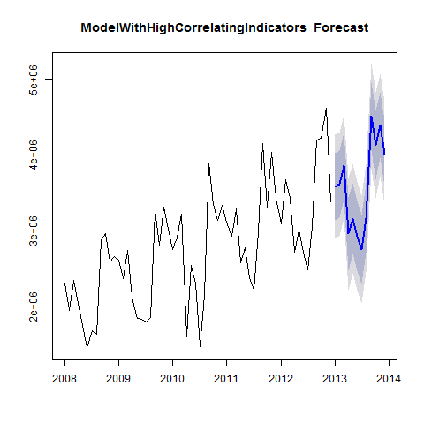

Figure 25

```r
print(head(ModelWithHighCorrelatingIndicators_Forecast))
```

```
## $model
##
## Call:
## tslm(formula = TotalAsIs_2012 ~ trend + season + CEPI_2012 +
##     SIExtern_2012 + UrbanoExports_2012 + GlobalisationPartyMembers_2012 +
##     AEPI_2012)
##
## Coefficients:
##                    (Intercept)                           trend
##                     -1.542e+07                       2.827e+02
##                        season2                         season3
##                     -1.071e+05                       6.219e+04
##                        season4                         season5
##                     -7.186e+05                      -5.757e+05
##                        season6                         season7
##                     -8.241e+05                      -1.083e+06
##                        season8                         season9
##                     -6.963e+05                       6.649e+05
##                       season10                        season11
##                      3.046e+05                       5.136e+05
##                       season12                       CEPI_2012
##                      4.974e+04                       2.248e+05
##                  SIExtern_2012              UrbanoExports_2012
##                      2.369e+04                      -1.522e-01
## GlobalisationPartyMembers_2012                       AEPI_2012
##                      3.142e+01                      -4.974e+04
##
##
## $mean
##          Jan     Feb     Mar     Apr     May     Jun     Jul     Aug
## 2013 3588409 3615751 3857685 2959830 3163014 2934791 2755659 3167751
##          Sep     Oct     Nov     Dec
## 2013 4512206 4129962 4398869 4019999
##
## $lower
##             [,1]    [,2]
## Jan 2013 3145307 2901625
## Feb 2013 3174780 2932271
## Mar 2013 3418316 3176687
## Apr 2013 2478742 2214171
```

[output cut: 25 more lines]

```
## [1] 80 95
##
## $x
##          Jan     Feb     Mar     Apr     May     Jun     Jul     Aug
## 2008 2313221 1950131 2346635 2039787 1756964 1458302 1679637 1639670
## 2009 2610573 2371327 2743786 2125308 1850073 1836222 1797311 1851968
## 2010 2760688 2918333 3227041 1613888 2550157 2317645 1474144 2148521
## 2011 3112861 2926663 3294784 2577079 2774068 2378227 2222900 2991787
## 2012 3093088 3679308 3433364 2714899 3011767 2726028 2483834 3055655
##          Sep     Oct     Nov     Dec
## 2008 2882886 2959716 2596494 2656568
## 2009 3271171 2818888 3310776 3022513
## 2010 3898571 3348953 3135945 3332886
## 2011 4151531 3318684 4037076 3429843
## 2012 4200796 4228724 4618540 3383673
```

In order to be able to correlate the Forecast with the As Is Data, it is necessary to convert the Point Estimator into a time series. Correlation of the forecasts and As Is Data. As a comparison, the correlation of the As Is Data for 2013 with the Plan Data.

```r
print(cor(ModelWithHighCorrelatingIndicators_PointForecast, TotalAsIs_2013))
```

```
## [1] 0.9028604
```

```r
print(cor(TotalAsIs_2013, TotalPlan_2013))
```

```
## [1] 0.929769
```

A Comparison with linear regression also supports the result.

```r
print(summary(ModelWithHighCorrelatingIndicators_forecast_lm))
```

```
##
## Call:
## lm(formula = TotalAsIs_2013 ~ ModelWithHighCorrelatingIndicators_PointForecast,
##     data = TotalAsIs_2013)
##
## Residuals:
##     Min      1Q  Median      3Q     Max
## -540546 -227283   12596  157487  731430
##
## Coefficients:
##                                                    Estimate Std. Error
## (Intercept)                                      -5.082e+05  6.545e+05
## ModelWithHighCorrelatingIndicators_PointForecast  1.195e+00  1.799e-01
##                                                  t value Pr(>|t|)
## (Intercept)                                       -0.776    0.455
## ModelWithHighCorrelatingIndicators_PointForecast   6.641 5.78e-05 ***
## ---
## Signif. codes:  0 '***' 0.001 '**' 0.01 '*' 0.05 '.' 0.1 ' ' 1
##
## Residual standard error: 357000 on 10 degrees of freedom
## Multiple R-squared:  0.8152, Adjusted R-squared:  0.7967
## F-statistic:  44.1 on 1 and 10 DF,  p-value: 5.776e-05
```

```r
print(summary(TotalAsIs_2013_lm))
```

```
##
## Call:
## lm(formula = TotalAsIs_2013 ~ TotalPlan_2013, data = TotalAsIs_2013)
##
## Residuals:
##     Min      1Q  Median      3Q     Max
## -441885 -227385  -43470  184761  466401
##
## Coefficients:
##                  Estimate Std. Error t value Pr(>|t|)
## (Intercept)    -8.972e+04  4.930e+05  -0.182    0.859
## TotalPlan_2013  1.053e+00  1.318e-01   7.987  1.2e-05 ***
## ---
## Signif. codes:  0 '***' 0.001 '**' 0.01 '*' 0.05 '.' 0.1 ' ' 1
##
## Residual standard error: 305700 on 10 degrees of freedom
## Multiple R-squared:  0.8645, Adjusted R-squared:  0.8509
## F-statistic: 63.78 on 1 and 10 DF,  p-value: 1.195e-05
```

Forecast ModelWithLowCorrelatingIndicators  
Shorten ModelWithLowCorrelatingIndicators by one year in order to be able to produce a forecast for 2013.

```r
print(summary(ModelWithLowCorrelatingIndicators_2012))
```

```
##
## Call:
## tslm(formula = TotalAsIs_2012 ~ trend + season + NationalHolidays_2012 +
##     UrbanoExports_2012 + GlobalisationPartyMembers_2012)
##
## Residuals:
##     Min      1Q  Median      3Q     Max
## -508808 -130098   11746  177748  466017
##
## Coefficients:
##                                  Estimate Std. Error t value Pr(>|t|)
## (Intercept)                     1.211e+06  1.549e+06   0.782 0.438428
## trend                           2.004e+04  1.028e+04   1.950 0.057515 .
## season2                        -2.898e+04  1.573e+05  -0.184 0.854714
## season3                         2.520e+05  1.631e+05   1.545 0.129609
## season4                        -3.800e+05  2.242e+05  -1.695 0.097100 .
## season5                        -4.697e+05  1.623e+05  -2.894 0.005897 **
## season6                        -7.350e+05  1.652e+05  -4.450 5.79e-05 ***
## season7                        -9.668e+05  1.687e+05  -5.732 8.35e-07 ***
## season8                        -5.809e+05  1.727e+05  -3.364 0.001602 **
## season9                         7.426e+05  1.772e+05   4.190 0.000132 ***
## season10                        3.765e+05  1.822e+05   2.066 0.044712 *
## season11                        5.612e+05  1.876e+05   2.991 0.004541 **
## season12                        4.716e+05  2.756e+05   1.711 0.094062 .
## NationalHolidays_2012          -3.051e+05  1.962e+05  -1.554 0.127234
## UrbanoExports_2012              1.218e-01  1.838e-01   0.663 0.510937
## GlobalisationPartyMembers_2012  5.692e+00  2.753e+01   0.207 0.837165
## ---
## Signif. codes:  0 '***' 0.001 '**' 0.01 '*' 0.05 '.' 0.1 ' ' 1
##
## Residual standard error: 248200 on 44 degrees of freedom
## Multiple R-squared:  0.9162, Adjusted R-squared:  0.8876
## F-statistic: 32.05 on 15 and 44 DF,  p-value: < 2.2e-16
```

Add “newdata” to the 2013 indicator values for the forecast

```r
print(head(ModelWithLowCorrelatingIndicators_Forecast))
```

```
## $model
##
## Call:
## tslm(formula = TotalAsIs_2012 ~ trend + season + NationalHolidays_2012 +
##     UrbanoExports_2012 + GlobalisationPartyMembers_2012)
##
## Coefficients:
##                    (Intercept)                           trend
##                      1.211e+06                       2.004e+04
##                        season2                         season3
##                     -2.898e+04                       2.520e+05
##                        season4                         season5
##                     -3.800e+05                      -4.697e+05
##                        season6                         season7
##                     -7.350e+05                      -9.668e+05
##                        season8                         season9
##                     -5.809e+05                       7.426e+05
##                       season10                        season11
##                      3.765e+05                       5.612e+05
##                       season12           NationalHolidays_2012
##                      4.716e+05                      -3.051e+05
##             UrbanoExports_2012  GlobalisationPartyMembers_2012
##                      1.218e-01                       5.692e+00
##
##
## $mean
##          Jan     Feb     Mar     Apr     May     Jun     Jul     Aug
## 2013 3703214 3694280 3690209 3383361 3313734 3068413 2856693 3262648
##          Sep     Oct     Nov     Dec
## 2013 4606119 4260121 4464894 4090225
##
## $lower
##             [,1]    [,2]
## Jan 2013 3306827 3089217
## Feb 2013 3297893 3080283
## Mar 2013 3244288 2999485
## Apr 2013 2937440 2692637
## May 2013 2917347 2699736
## Jun 2013 2672026 2454415
## Jul 2013 2460306 2242696
```

[output cut: 22 more lines]

```
## [1] 80 95
##
## $x
##          Jan     Feb     Mar     Apr     May     Jun     Jul     Aug
## 2008 2313221 1950131 2346635 2039787 1756964 1458302 1679637 1639670
## 2009 2610573 2371327 2743786 2125308 1850073 1836222 1797311 1851968
## 2010 2760688 2918333 3227041 1613888 2550157 2317645 1474144 2148521
## 2011 3112861 2926663 3294784 2577079 2774068 2378227 2222900 2991787
## 2012 3093088 3679308 3433364 2714899 3011767 2726028 2483834 3055655
##          Sep     Oct     Nov     Dec
## 2008 2882886 2959716 2596494 2656568
## 2009 3271171 2818888 3310776 3022513
## 2010 3898571 3348953 3135945 3332886
## 2011 4151531 3318684 4037076 3429843
## 2012 4200796 4228724 4618540 3383673
```

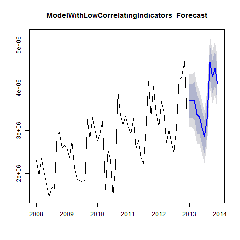

Figure 26

```r
print(cor(ModelWithLowCorrelatingIndicators_PointForecast, TotalAsIs_2013))
```

```
## [1] 0.9590162
```

```r
print(cor(TotalAsIs_2013, TotalPlan_2013))
```

```
## [1] 0.929769
```

A Comparison with linear regression also supports the result.

```r
print(summary(ModelWithLowCorrelatingIndicators_forecast_lm))
```

```
##
## Call:
## lm(formula = TotalAsIs_2013 ~ ModelWithLowCorrelatingIndicators_PointForecast,
##     data = TotalAsIs_2013)
##
## Residuals:
##     Min      1Q  Median      3Q     Max
## -299026 -155463  -40768  115237  406333
##
## Coefficients:
##                                                   Estimate Std. Error
## (Intercept)                                     -1.252e+06  4.754e+05
## ModelWithLowCorrelatingIndicators_PointForecast  1.361e+00  1.272e-01
##                                                 t value Pr(>|t|)
## (Intercept)                                      -2.633    0.025 *
## ModelWithLowCorrelatingIndicators_PointForecast  10.703  8.5e-07 ***
## ---
## Signif. codes:  0 '***' 0.001 '**' 0.01 '*' 0.05 '.' 0.1 ' ' 1
##
## Residual standard error: 235300 on 10 degrees of freedom
## Multiple R-squared:  0.9197, Adjusted R-squared:  0.9117
## F-statistic: 114.6 on 1 and 10 DF,  p-value: 8.5e-07
```

```r
print(summary(TotalAsIs_2013_lm))
```

```
##
## Call:
## lm(formula = TotalAsIs_2013 ~ TotalPlan_2013, data = TotalAsIs_2013)
##
## Residuals:
##     Min      1Q  Median      3Q     Max
## -441885 -227385  -43470  184761  466401
##
## Coefficients:
##                  Estimate Std. Error t value Pr(>|t|)
## (Intercept)    -8.972e+04  4.930e+05  -0.182    0.859
## TotalPlan_2013  1.053e+00  1.318e-01   7.987  1.2e-05 ***
## ---
## Signif. codes:  0 '***' 0.001 '**' 0.01 '*' 0.05 '.' 0.1 ' ' 1
##
## Residual standard error: 305700 on 10 degrees of freedom
## Multiple R-squared:  0.8645, Adjusted R-squared:  0.8509
## F-statistic: 63.78 on 1 and 10 DF,  p-value: 1.195e-05
```

#### Forecast ModelWithTrendAndSeasonalityOnly:

Shorten ModelWithTrendAndSeasonalityOnly by one year in order to be able to produce a forecast for 2013.

```r
print(summary(ModelWithTrendAndSeasonalityOnly_2012))
```

```
##
## Call:
## tslm(formula = TotalAsIs_2012 ~ trend + season)
##
## Residuals:
##     Min      1Q  Median      3Q     Max
## -600304 -116717   -7864  163111  473692
##
## Coefficients:
##             Estimate Std. Error t value Pr(>|t|)
## (Intercept)  2147793     120530  17.820  < 2e-16 ***
## trend          25212       1887  13.363  < 2e-16 ***
## season2       -34146     156872  -0.218 0.828632
## season3       180612     156906   1.151 0.255518
## season4      -639529     156962  -4.074 0.000176 ***
## season5      -490327     157042  -3.122 0.003068 **
## season6      -760860     157144  -4.842 1.43e-05 ***
## season7      -997792     157268  -6.345 8.09e-08 ***
## season8      -617048     157415  -3.920 0.000286 ***
## season9       701211     157585   4.450 5.26e-05 ***
## season10      330001     157777   2.092 0.041907 *
## season11      509563     157991   3.225 0.002292 **
## season12      109681     158227   0.693 0.491603
## ---
## Signif. codes:  0 '***' 0.001 '**' 0.01 '*' 0.05 '.' 0.1 ' ' 1
##
## Residual standard error: 248000 on 47 degrees of freedom
## Multiple R-squared:  0.9106, Adjusted R-squared:  0.8878
## F-statistic: 39.89 on 12 and 47 DF,  p-value: < 2.2e-16
```

Add “newdata” to the 2013 indicator values for the forecast.

```r
print(head(ModelWithTrendAndSeasonalityOnly_Forecast))
```

```
## $model
##
## Call:
## tslm(formula = TotalAsIs_2012 ~ trend + season)
##
## Coefficients:
## (Intercept)        trend      season2      season3      season4
##     2147793        25212       -34146       180612      -639529
##     season5      season6      season7      season8      season9
##     -490327      -760860      -997791      -617048       701211
##    season10     season11     season12
##      330001       509563       109681
##
##
## $mean
##          Jan     Feb     Mar     Apr     May     Jun     Jul     Aug
## 2013 3685709 3676775 3916745 3121815 3296229 3050908 2839188 3245143
##          Sep     Oct     Nov     Dec
## 2013 4588614 4242616 4447389 4072720
##
## $lower
##             [,1]    [,2]
## Jan 2013 3321691 3122318
## Feb 2013 3312757 3113384
## Mar 2013 3552727 3353354
## Apr 2013 2757797 2558424
## May 2013 2932211 2732838
## Jun 2013 2686890 2487517
## Jul 2013 2475170 2275797
## Aug 2013 2881125 2681752
## Sep 2013 4224596 4025223
## Oct 2013 3878598 3679225
## Nov 2013 4083371 3883998
## Dec 2013 3708702 3509329
##
## $upper
##             [,1]    [,2]
## Jan 2013 4049727 4249100
## Feb 2013 4040793 4240166
## Mar 2013 4280763 4480136
```

[output cut: 11 more lines]

```
## [1] 80 95
##
## $x
##          Jan     Feb     Mar     Apr     May     Jun     Jul     Aug
## 2008 2313221 1950131 2346635 2039787 1756964 1458302 1679637 1639670
## 2009 2610573 2371327 2743786 2125308 1850073 1836222 1797311 1851968
## 2010 2760688 2918333 3227041 1613888 2550157 2317645 1474144 2148521
## 2011 3112861 2926663 3294784 2577079 2774068 2378227 2222900 2991787
## 2012 3093088 3679308 3433364 2714899 3011767 2726028 2483834 3055655
##          Sep     Oct     Nov     Dec
## 2008 2882886 2959716 2596494 2656568
## 2009 3271171 2818888 3310776 3022513
## 2010 3898571 3348953 3135945 3332886
## 2011 4151531 3318684 4037076 3429843
## 2012 4200796 4228724 4618540 3383673
```

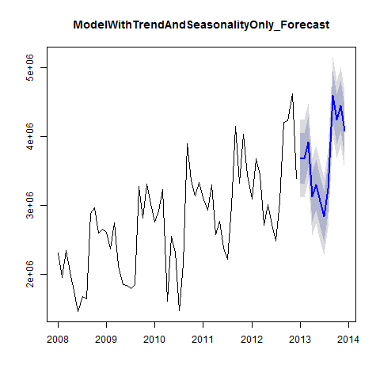

Figure 27

In order to be able to correlate the Forecast with the As Is Data, it is necessary to convert the Point Estimator into a time series. Correlation of the forecasts and As Is Data. As a comparison, the correlation of the As Is Data for 2013 with the Plan Data.

```r
print(cor(ModelWithTrendAndSeasonalityOnly_PointForecast, TotalAsIs_2013) )
```

```
## [1] 0.9138049
```

```r
print(cor(TotalAsIs_2013, TotalPlan_2013))
```

```
## [1] 0.929769
```

A Comparison with linear regression also supports the result

```r
print(summary(ModelWithTrendAndSeasonalityOnly_Forecast_lm))
```

```
##
## Call:
## lm(formula = TotalAsIs_2013 ~ ModelWithTrendAndSeasonalityOnly_PointForecast,
##     data = TotalAsIs_2013)
##
## Residuals:
##     Min      1Q  Median      3Q     Max
## -516239 -216450   33683  123007  675607
##
## Coefficients:
##                                                  Estimate Std. Error
## (Intercept)                                    -8.142e+05  6.536e+05
## ModelWithTrendAndSeasonalityOnly_PointForecast  1.249e+00  1.755e-01
##                                                t value Pr(>|t|)
## (Intercept)                                     -1.246    0.241
## ModelWithTrendAndSeasonalityOnly_PointForecast   7.115 3.24e-05 ***
## ---
## Signif. codes:  0 '***' 0.001 '**' 0.01 '*' 0.05 '.' 0.1 ' ' 1
##
## Residual standard error: 337300 on 10 degrees of freedom
## Multiple R-squared:  0.835,  Adjusted R-squared:  0.8185
## F-statistic: 50.62 on 1 and 10 DF,  p-value: 3.238e-05
```

```r
print(summary(TotalAsIs_2013_lm))
```

```
##
## Call:
## lm(formula = TotalAsIs_2013 ~ TotalPlan_2013, data = TotalAsIs_2013)
##
## Residuals:
##     Min      1Q  Median      3Q     Max
## -441885 -227385  -43470  184761  466401
##
## Coefficients:
##                  Estimate Std. Error t value Pr(>|t|)
## (Intercept)    -8.972e+04  4.930e+05  -0.182    0.859
## TotalPlan_2013  1.053e+00  1.318e-01   7.987  1.2e-05 ***
## ---
## Signif. codes:  0 '***' 0.001 '**' 0.01 '*' 0.05 '.' 0.1 ' ' 1
##
## Residual standard error: 305700 on 10 degrees of freedom
## Multiple R-squared:  0.8645, Adjusted R-squared:  0.8509
## F-statistic: 63.78 on 1 and 10 DF,  p-value: 1.195e-05
```

#### Forecast ModelTotalEtel

Shorten the variables in ModelTotalEtel by one year in order to be able to produce a forecast for 2013.

```r
print(summary(ModelTotalEtel_2012))
```

```
##
## Call:
## tslm(formula = TotalEtelAsIs_2012 ~ trend + season)
##
## Residuals:
##     Min      1Q  Median      3Q     Max
## -299816  -89175   -2539  108720  287047
##
## Coefficients:
##             Estimate Std. Error t value Pr(>|t|)
## (Intercept)  1361585      78100  17.434  < 2e-16 ***
## trend           6460       1223   5.284 3.20e-06 ***
## season2       -44872     101648  -0.441  0.66091
## season3       -53014     101671  -0.521  0.60452
## season4      -524858     101707  -5.160 4.88e-06 ***
## season5      -501638     101759  -4.930 1.07e-05 ***
## season6      -674802     101825  -6.627 3.01e-08 ***
## season7      -765417     101905  -7.511 1.38e-09 ***
## season8      -544231     102001  -5.336 2.68e-06 ***
## season9       558436     102111   5.469 1.70e-06 ***
## season10      232677     102235   2.276  0.02745 *
## season11      276582     102374   2.702  0.00957 **
## season12       55396     102527   0.540  0.59154
## ---
## Signif. codes:  0 '***' 0.001 '**' 0.01 '*' 0.05 '.' 0.1 ' ' 1
##
## Residual standard error: 160700 on 47 degrees of freedom
## Multiple R-squared:  0.9008, Adjusted R-squared:  0.8755
## F-statistic: 35.58 on 12 and 47 DF,  p-value: < 2.2e-16
```

#### Forecast:

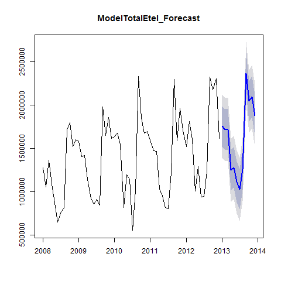

Figure 28

```r
print(head(ModelTotalEtel_Forecast))
```

```
## $model
##
## Call:
## tslm(formula = TotalEtelAsIs_2012 ~ trend + season)
##
## Coefficients:
## (Intercept)        trend      season2      season3      season4
##     1361585         6460       -44872       -53014      -524858
##     season5      season6      season7      season8      season9
##     -501638      -674802      -765417      -544231       558436
##    season10     season11     season12
##      232677       276582        55396
##
##
## $mean
##          Jan     Feb     Mar     Apr     May     Jun     Jul     Aug
## 2013 1755615 1717202 1715520 1250135 1279815 1113110 1028955 1256600
##          Sep     Oct     Nov     Dec
## 2013 2365726 2046428 2096791 1882065
##
## $lower
##               [,1]      [,2]
## Jan 2013 1519741.4 1390553.3
## Feb 2013 1481328.6 1352140.5
## Mar 2013 1479646.6 1350458.5
## Apr 2013 1014262.0  885073.9
## May 2013 1043941.8  914753.7
## Jun 2013  877236.8  748048.7
## Jul 2013  793081.8  663893.7
## Aug 2013 1020727.0  891538.9
## Sep 2013 2129853.0 2000664.9
## Oct 2013 1810554.4 1681366.3
## Nov 2013 1860918.0 1731729.9
## Dec 2013 1646192.0 1517003.9
##
## $upper
##             [,1]    [,2]
## Jan 2013 1991488 2120676
## Feb 2013 1953076 2082264
## Mar 2013 1951394 2080582
```

[output cut: 11 more lines]

```
## [1] 80 95
##
## $x
##          Jan     Feb     Mar     Apr     May     Jun     Jul     Aug
## 2008 1279668 1053325 1367520 1090725  873568  644479  772658  806741
## 2009 1583216 1407388 1420801 1141100  919860  858876  910134  843050
## 2010 1637464 1676161 1549560  813469 1198401 1140024  551268 1012542
## 2011 1595267 1473528 1469728 1034650  952553  819303  802076 1222812
## 2012 1519748 1812897 1607280 1008022 1291983  940158  945929 1235146
##          Sep     Oct     Nov     Dec
## 2008 1715265 1795751 1518288 1601324
## 2009 1981563 1647934 1857836 1615091
## 2010 2335488 1856264 1678123 1699063
## 2011 2303271 1591584 1960675 1713991
## 2012 2330334 2177895 2306324 1618147
```

In order to be able to correlate the Forecast with the As Is Data, it is necessary to convert the Point Estimator into a time series.  
Correlation of the forecasts and As Is Data. As a comparison, the correlation of the As Is Data for 2013 with the Plan Data.

```r
print(cor(ModelTotalEtel_PointForecast, TotalEtelAsIs_2013))
```

```
## [1] 0.9392717
```

```r
print(cor(TotalEtelPlan_2013, TotalEtelAsIs_2013))
```

```
## [1] 0.9602983
```

#### Forecast ModelWithTotalUrbanoExports

Shorten the variables in ModelWithTotalUrbanoExports by one year in order to be able to produce a forecast for 2013.

```r
print(summary(ModelWithTotalUrbanoExports_2012))
```

```
##
## Call:
## tslm(formula = TotalAsIs_2012 ~ trend + season + UrbanoExports_2012)
##
## Residuals:
##     Min      1Q  Median      3Q     Max
## -569149 -128266    8067  181935  457990
##
## Coefficients:
##                      Estimate Std. Error t value Pr(>|t|)
## (Intercept)         1.450e+06  1.039e+06   1.396 0.169437
## trend               2.187e+04  5.296e+03   4.129 0.000152 ***
## season2            -3.080e+04  1.579e+05  -0.195 0.846161
## season3             1.873e+05  1.581e+05   1.184 0.242307
## season4            -6.295e+05  1.586e+05  -3.970 0.000250 ***
## season5            -4.770e+05  1.592e+05  -2.996 0.004395 **
## season6            -7.441e+05  1.600e+05  -4.651 2.80e-05 ***
## season7            -9.777e+05  1.609e+05  -6.075 2.23e-07 ***
## season8            -5.936e+05  1.621e+05  -3.663 0.000643 ***
## season9             7.280e+05  1.634e+05   4.456 5.31e-05 ***
## season10            3.601e+05  1.648e+05   2.185 0.034032 *
## season11            5.430e+05  1.664e+05   3.263 0.002084 **
## season12            1.465e+05  1.682e+05   0.871 0.388352
## UrbanoExports_2012  1.246e-01  1.843e-01   0.676 0.502194
## ---
## Signif. codes:  0 '***' 0.001 '**' 0.01 '*' 0.05 '.' 0.1 ' ' 1
##
## Residual standard error: 249500 on 46 degrees of freedom
## Multiple R-squared:  0.9115, Adjusted R-squared:  0.8864
## F-statistic: 36.43 on 13 and 46 DF,  p-value: < 2.2e-16
```

Add “newdata” to the 2013 indicator values for the forecast.

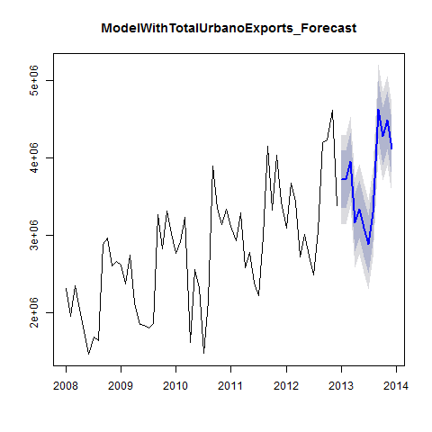

Figure 29

```r
print(head(ModelWithTotalUrbanoExports_Forecast))
```

```
## $model
##
## Call:
## tslm(formula = TotalAsIs_2012 ~ trend + season + UrbanoExports_2012)
##
## Coefficients:
##        (Intercept)               trend             season2
##          1.450e+06           2.187e+04          -3.080e+04
##            season3             season4             season5
##          1.873e+05          -6.295e+05          -4.770e+05
##            season6             season7             season8
##         -7.441e+05          -9.777e+05          -5.936e+05
##            season9            season10            season11
##          7.280e+05           3.601e+05           5.430e+05
##           season12  UrbanoExports_2012
##          1.465e+05           1.246e-01
##
##
## $mean
##          Jan     Feb     Mar     Apr     May     Jun     Jul     Aug
## 2013 3724840 3715906 3955876 3160946 3335360 3090039 2878319 3284274
##          Sep     Oct     Nov     Dec
## 2013 4627745 4281747 4486520 4111851
##
## $lower
##             [,1]    [,2]
## Jan 2013 3350944 3146008
## Feb 2013 3342010 3137074
## Mar 2013 3581980 3377044
## Apr 2013 2787050 2582114
## May 2013 2961464 2756527
## Jun 2013 2716143 2511206
## Jul 2013 2504423 2299487
## Aug 2013 2910378 2705442
## Sep 2013 4253849 4048913
## Oct 2013 3907851 3702915
## Nov 2013 4112624 3907688
## Dec 2013 3737954 3533018
##
## $upper
```

[output cut: 15 more lines]

```
## [1] 80 95
##
## $x
##          Jan     Feb     Mar     Apr     May     Jun     Jul     Aug
## 2008 2313221 1950131 2346635 2039787 1756964 1458302 1679637 1639670
## 2009 2610573 2371327 2743786 2125308 1850073 1836222 1797311 1851968
## 2010 2760688 2918333 3227041 1613888 2550157 2317645 1474144 2148521
## 2011 3112861 2926663 3294784 2577079 2774068 2378227 2222900 2991787
## 2012 3093088 3679308 3433364 2714899 3011767 2726028 2483834 3055655
##          Sep     Oct     Nov     Dec
## 2008 2882886 2959716 2596494 2656568
## 2009 3271171 2818888 3310776 3022513
## 2010 3898571 3348953 3135945 3332886
## 2011 4151531 3318684 4037076 3429843
## 2012 4200796 4228724 4618540 3383673
```

In order to be able to correlate the Forecast with the As Is data, it is necessary to convert the Point Estimator into a time series. Correlation of the forecasts and As Is Data. As a comparison, the correlation of the As Is Data for 2013 with the Plan Data.

```r
print(cor(ModelWithTotalUrbanoExports_PointForecast, TotalAsIs_2013) )
```

```
## [1] 0.9138049
```

```r
print(cor(TotalAsIs_2013, TotalPlan_2013))
```

```
## [1] 0.929769
```

#### Forecast ModelWithNationalHolidays

Shorten the variables in ModelWithNationalHolidays by one year in order to be able to produce a forecast for 2013.

```r
print(summary(ModelWithNationalHolidays_2012))
```

```
##
## Call:
## tslm(formula = TotalAsIs_2012 ~ trend + season + NationalHolidays_2012)
##
## Residuals:
##     Min      1Q  Median      3Q     Max
## -539294 -116717   -7864  163111  473692
##
## Coefficients:
##                       Estimate Std. Error t value Pr(>|t|)
## (Intercept)            2147793     118654  18.101  < 2e-16 ***
## trend                    25212       1857  13.574  < 2e-16 ***
## season2                 -34146     154431  -0.221 0.825988
## season3                 241623     159215   1.518 0.135962
## season4                -395488     218453  -1.810 0.076768 .
## season5                -490327     154598  -3.172 0.002699 **
## season6                -760860     154698  -4.918 1.16e-05 ***
## season7                -997792     154821  -6.445 6.22e-08 ***
## season8                -617048     154966  -3.982 0.000241 ***
## season9                 701211     155133   4.520 4.31e-05 ***
## season10                330001     155322   2.125 0.039022 *
## season11                509563     155532   3.276 0.002005 **
## season12                414732     248034   1.672 0.101299
## NationalHolidays_2012  -305051     193024  -1.580 0.120873
## ---
## Signif. codes:  0 '***' 0.001 '**' 0.01 '*' 0.05 '.' 0.1 ' ' 1
##
## Residual standard error: 244200 on 46 degrees of freedom
## Multiple R-squared:  0.9152, Adjusted R-squared:  0.8912
## F-statistic: 38.19 on 13 and 46 DF,  p-value: < 2.2e-16
```

Add “newdata” to the 2013 indicator values for the forecast.

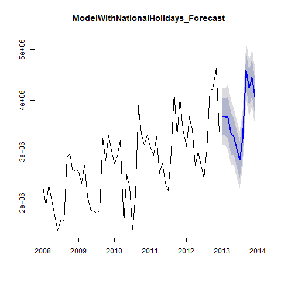

Figure 30

```r
print(head(ModelWithNationalHolidays_Forecast))
```

```
## $model
##
## Call:
## tslm(formula = TotalAsIs_2012 ~ trend + season + NationalHolidays_2012)
##
## Coefficients:
##           (Intercept)                  trend                season2
##               2147793                  25212                 -34146
##               season3                season4                season5
##                241623                -395488                -490327
##               season6                season7                season8
##               -760860                -997791                -617048
##               season9               season10               season11
##                701211                 330001                 509563
##              season12  NationalHolidays_2012
##                414732                -305051
##
##
## $mean
##          Jan     Feb     Mar     Apr     May     Jun     Jul     Aug
## 2013 3685709 3676775 3672704 3365856 3296229 3050908 2839188 3245143
##          Sep     Oct     Nov     Dec
## 2013 4588614 4242616 4447389 4072720
##
## $lower
##             [,1]    [,2]
## Jan 2013 3327245 3130767
## Feb 2013 3318311 3121833
## Mar 2013 3261840 3036641
## Apr 2013 2954992 2729793
## May 2013 2937764 2741286
## Jun 2013 2692443 2495965
## Jul 2013 2480724 2284246
## Aug 2013 2886679 2690201
## Sep 2013 4230149 4033671
## Oct 2013 3884151 3687673
## Nov 2013 4088925 3892447
## Dec 2013 3714255 3517777
##
## $upper
```

[output cut: 15 more lines]

```
## [1] 80 95
##
## $x
##          Jan     Feb     Mar     Apr     May     Jun     Jul     Aug
## 2008 2313221 1950131 2346635 2039787 1756964 1458302 1679637 1639670
## 2009 2610573 2371327 2743786 2125308 1850073 1836222 1797311 1851968
## 2010 2760688 2918333 3227041 1613888 2550157 2317645 1474144 2148521
## 2011 3112861 2926663 3294784 2577079 2774068 2378227 2222900 2991787
## 2012 3093088 3679308 3433364 2714899 3011767 2726028 2483834 3055655
##          Sep     Oct     Nov     Dec
## 2008 2882886 2959716 2596494 2656568
## 2009 3271171 2818888 3310776 3022513
## 2010 3898571 3348953 3135945 3332886
## 2011 4151531 3318684 4037076 3429843
## 2012 4200796 4228724 4618540 3383673
```

In order to be able to correlate the Forecast with the As Is data, it is necessary to convert the Point Estimator into a time series. Correlation of the forecasts and As Is Data. As a comparison, the correlation of the As Is data for 2013 with the Plan Data.

```r
print(cor(ModelWithNationalHolidays_PointForecast, TotalAsIs_2013) )
```

```
## [1] 0.9590162
```

#### Forecast ModelWithInfluenceNationalHolidays

Add “newdata” to the 2013 indicator values for the forecast.

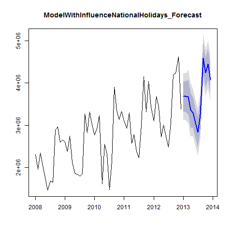

Figure 31

```r
print(head(ModelWithInfluenceNationalHolidays_Forecast, 10))
```

```
## $model
##
## Call:
## tslm(formula = TotalAsIs_2012 ~ trend + season + InfluenceNationalHolidays_2012)
##
## Coefficients:
##                    (Intercept)                           trend
##                        2147793                           25212
##                        season2                         season3
##                         -34146                          241623
##                        season4                         season5
##                        -395488                         -490327
##                        season6                         season7
##                        -760860                         -997791
##                        season8                         season9
##                        -617048                         1006262
##                       season10                        season11
##                         330001                          814614
##                       season12  InfluenceNationalHolidays_2012
##                         414732                         -305051
##
##
## $mean
##          Jan     Feb     Mar     Apr     May     Jun     Jul     Aug
## 2013 3685709 3676775 3672704 3365856 3296229 3050908 2839188 3245143
##          Sep     Oct     Nov     Dec
## 2013 4588614 4242616 4447389 4072720
##
## $lower
##             [,1]    [,2]
## Jan 2013 3327245 3130767
## Feb 2013 3318311 3121833
## Mar 2013 3261840 3036641
## Apr 2013 2954992 2729793
## May 2013 2937764 2741286
## Jun 2013 2692443 2495965
## Jul 2013 2480724 2284246
## Aug 2013 2886679 2690201
## Sep 2013 4230149 4033671
## Oct 2013 3884151 3687673
```

[output cut: 71 more lines]

```
## 2012  473691.850 -386505.550
##
## $fitted
##          Jan     Feb     Mar     Apr     May     Jun     Jul     Aug
## 2008 2173004 2164070 2159999 1853151 1783524 1538203 1326483 1732438
## 2009 2475545 2466611 2767591 1850641 2086065 1840744 1629024 2034979
## 2010 2778086 2769152 3070132 2153182 2388606 2143285 1931565 2337520
## 2011 3080627 3071693 3372673 2455723 2691147 2445826 2234106 2640061
## 2012 3383168 3374234 3675214 2758264 2993688 2748367 2536647 2942602
##          Sep     Oct     Nov     Dec
## 2008 3075909 2729911 2934684 2560015
## 2009 3378450 3032452 3237225 2862556
## 2010 3680991 3334993 3539766 3165097
## 2011 3983532 3637534 3842307 3467638
## 2012 4286073 3940075 4144848 3770179
```

In order to be able to correlate the Forecast with the As Is Data, it is necessary to convert the Point Estimator into a time series. Correlation of the forecasts and As Is Data. As a comparison, the correlation of the As Is Data for 2013 with the Plan Data.

```r
print(cor(ModelWithInfluenceNationalHolidays_PointForecast, TotalAsIs_2013))
```

```
## [1] 0.9590162
```

```r
print(cor(TotalAsIs_2013, TotalPlan_2013))
```

```
## [1] 0.929769
```

```r
print(cor(TotalAsIs_2013, TotalPlan_2013))
```

```
## [1] 0.929769
```

## 7.0 Forecast for 2014

The script *forecast2014.r* procuces a 2014 export forecast and alternate forecast. It also outputs both forecasts as CSV files.  
As ModelWithLowCorrelatingIndicators was the one of best fitting model for a forecast, the exports data for 2014 will be forecast based on trend and seasonality and NationalHolidays, UrbanoExports and GlobalisationPartyMembers.

```r
source("Scripts/forecast2014.r")
```

```r
print(summary(ModelWithLowCorrelatingIndicators))
```

```
##
## Call:
## tslm(formula = TotalAsIs ~ trend + season + NationalHolidays +
##     UrbanoExports + GlobalisationPartyMembers)
##
## Residuals:
##     Min      1Q  Median      3Q     Max
## -508755 -122676    7119  173089  403964
##
## Coefficients:
##                             Estimate Std. Error t value Pr(>|t|)
## (Intercept)                1.467e+06  1.517e+06   0.967 0.337647
## trend                      2.264e+04  9.148e+03   2.474 0.016399 *
## season2                   -1.274e+05  1.450e+05  -0.878 0.383528
## season3                    1.980e+05  1.546e+05   1.281 0.205562
## season4                   -3.100e+05  1.794e+05  -1.728 0.089424 .
## season5                   -6.084e+05  1.493e+05  -4.075 0.000146 ***
## season6                   -8.641e+05  1.518e+05  -5.693 4.78e-07 ***
## season7                   -1.056e+06  1.548e+05  -6.824 6.75e-09 ***
## season8                   -6.982e+05  1.583e+05  -4.411 4.72e-05 ***
## season9                    7.360e+05  1.622e+05   4.538 3.05e-05 ***
## season10                   3.341e+05  1.665e+05   2.007 0.049635 *
## season11                   5.100e+05  1.712e+05   2.979 0.004276 **
## season12                   5.471e+05  2.338e+05   2.341 0.022838 *
## NationalHolidays          -4.315e+05  1.535e+05  -2.811 0.006794 **
## UrbanoExports              1.622e-01  1.692e-01   0.959 0.341873
## GlobalisationPartyMembers -4.032e+00  2.086e+01  -0.193 0.847464
## ---
## Signif. codes:  0 '***' 0.001 '**' 0.01 '*' 0.05 '.' 0.1 ' ' 1
##
## Residual standard error: 250700 on 56 degrees of freedom
## Multiple R-squared:  0.9288, Adjusted R-squared:  0.9097
## F-statistic: 48.69 on 15 and 56 DF,  p-value: < 2.2e-16
```

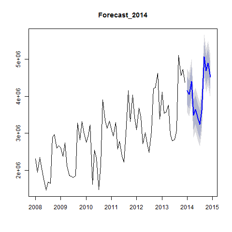

Figure 32

```r
print(PointForecast_ModelWithLowCorrelatingIndicators_2014)
```

```
##          Jan     Feb     Mar     Apr     May     Jun     Jul     Aug
## 2014 4154873 4050131 4398156 3481206 3637040 3403934 3234308 3615166
##          Sep     Oct     Nov     Dec
## 2014 5072002 4692732 4891237 4519491
```

```r
print(cor(TotalAsIs_2014,TotalPlan_2014))
```

```
## [1] 0.9448221
```

```r
print(cor(TotalAsIs_2014,PointForecast_ModelWithLowCorrelatingIndicators_2014))
```

```
## [1] 0.9178468
```

As ModelWithTrendAndSeasonalityOnly also gave a well fitting model for a forecast, the exports data for 2014 will be forecast based on trend and seasonality.

```r
print(summary(ModelWithTrendAndSeasonalityOnly) )
```

```
##
## Call:
## tslm(formula = TotalAsIs ~ trend + season)
##
## Residuals:
##     Min      1Q  Median      3Q     Max
## -699390 -154210   17753  150363  495430
##
## Coefficients:
##             Estimate Std. Error t value Pr(>|t|)
## (Intercept)  2182435     117276  18.609  < 2e-16 ***
## trend          26427       1514  17.456  < 2e-16 ***
## season2      -131168     152001  -0.863 0.391663
## season3        46585     152024   0.306 0.760356
## season4      -609102     152062  -4.006 0.000176 ***
## season5      -623539     152114  -4.099 0.000129 ***
## season6      -883072     152182  -5.803 2.74e-07 ***
## season7     -1079124     152265  -7.087 1.93e-09 ***
## season8      -724693     152363  -4.756 1.31e-05 ***
## season9       705716     152476   4.628 2.07e-05 ***
## season10      300019     152603   1.966 0.054009 .
## season11      472099     152746   3.091 0.003045 **
## season12       73925     152903   0.483 0.630546
## ---
## Signif. codes:  0 '***' 0.001 '**' 0.01 '*' 0.05 '.' 0.1 ' ' 1
##
## Residual standard error: 263300 on 59 degrees of freedom
## Multiple R-squared:  0.9173, Adjusted R-squared:  0.9004
## F-statistic: 54.51 on 12 and 59 DF,  p-value: < 2.2e-16
```

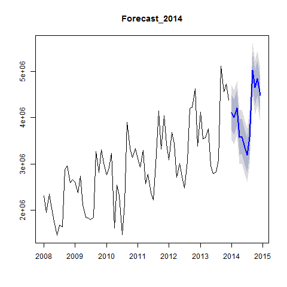

Figure 33

```r
cor(TotalAsIs_2014,TotalPlan_2014)
```

```
## [1] 0.9448221
```

```r
cor(TotalAsIs_2014,PointForecast_TrendAndSeasonality_2014)
```

```
## [1] 0.9349765
```

#### Alternative

```r
print(summary(ModelWithNationalHolidays))
```

```
##
## Call:
## tslm(formula = TotalAsIs ~ trend + season + NationalHolidays)
##
## Residuals:
##     Min      1Q  Median      3Q     Max
## -555545 -153976       4  150487  404837
##
## Coefficients:
##                  Estimate Std. Error t value Pr(>|t|)
## (Intercept)       2182435     110867  19.685  < 2e-16 ***
## trend               26427       1431  18.465  < 2e-16 ***
## season2           -131168     143696  -0.913  0.36512
## season3            190430     152432   1.249  0.21658
## season4           -321411     176034  -1.826  0.07302 .
## season5           -623539     143803  -4.336 5.86e-05 ***
## season6           -883072     143867  -6.138 8.06e-08 ***
## season7          -1079124     143945  -7.497 4.29e-10 ***
## season8           -724693     144037  -5.031 5.02e-06 ***
## season9            705716     144144   4.896 8.18e-06 ***
## season10           300019     144265   2.080  0.04199 *
## season11           472099     144400   3.269  0.00182 **
## season12           505461     210051   2.406  0.01932 *
## NationalHolidays  -431536     152405  -2.832  0.00636 **
## ---
## Signif. codes:  0 '***' 0.001 '**' 0.01 '*' 0.05 '.' 0.1 ' ' 1
##
## Residual standard error: 248900 on 58 degrees of freedom
## Multiple R-squared:  0.9273, Adjusted R-squared:  0.911
## F-statistic: 56.92 on 13 and 58 DF,  p-value: < 2.2e-16
```

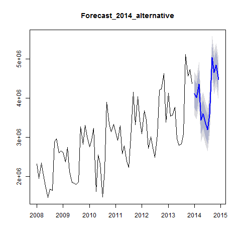

Figure 34

```r
print(head(PointForecast_2014_alternative))
```

```
## [1] 4111576 4006834 4354859 3437909 3593744 3360637
```

## 8.0 Developing Forecasting Models with Alternative Model Approaches

### 8.1 Exponential Smoothing

```r
source("Scripts/alternativeForecastModels.r")
```

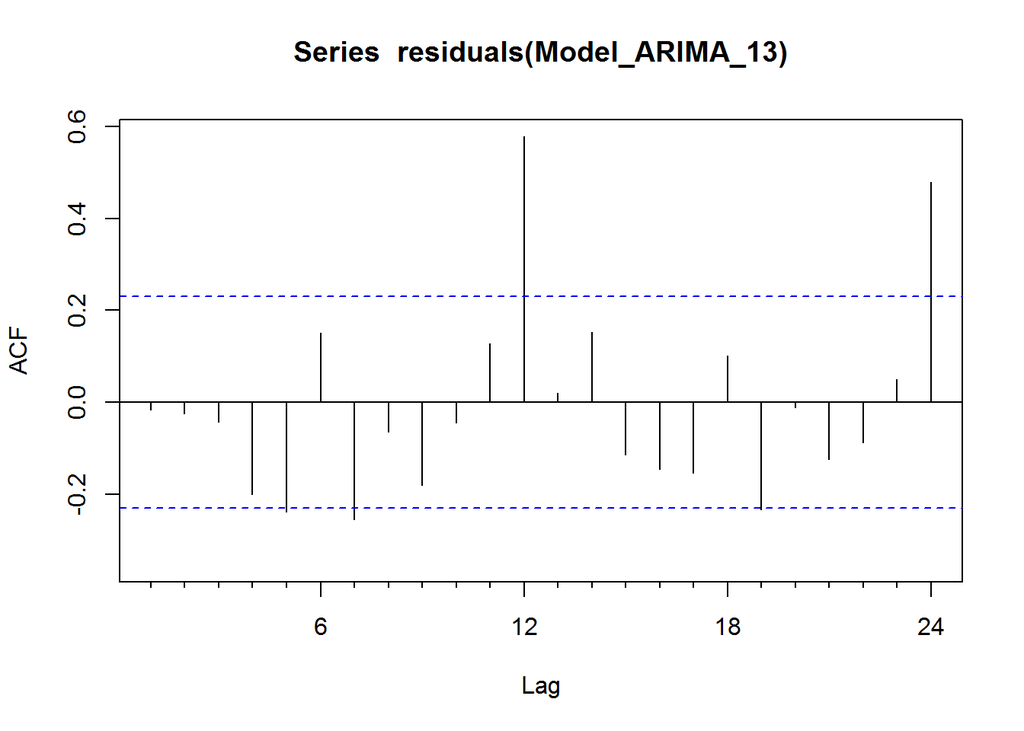

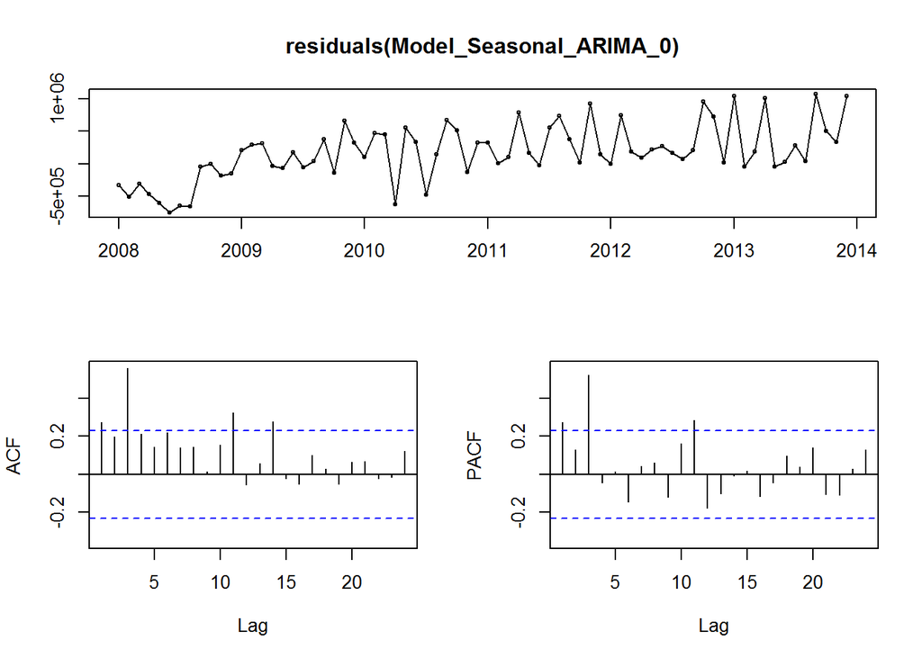

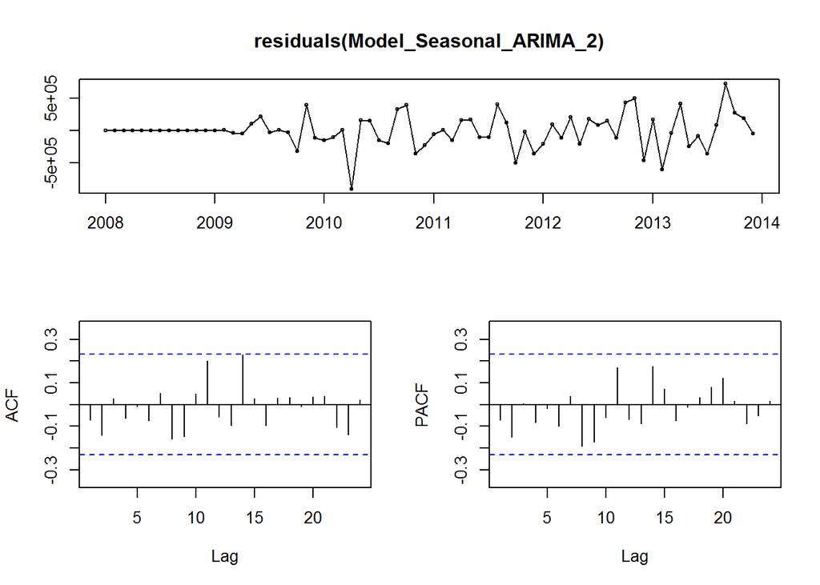

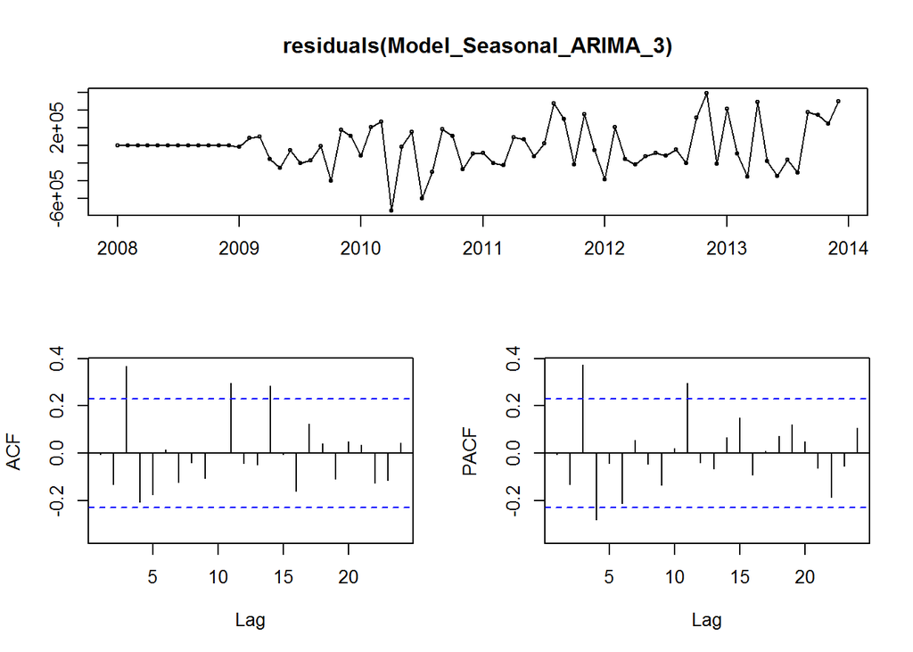

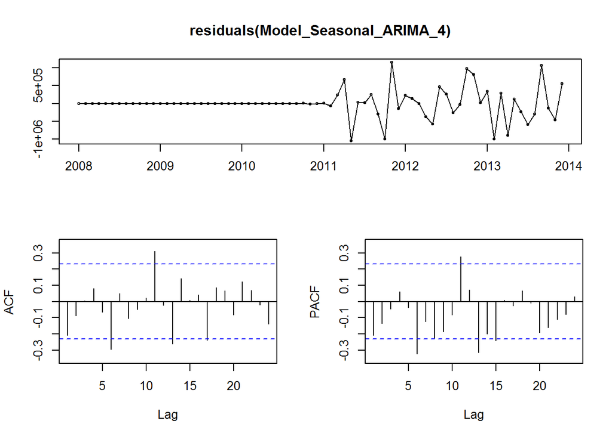

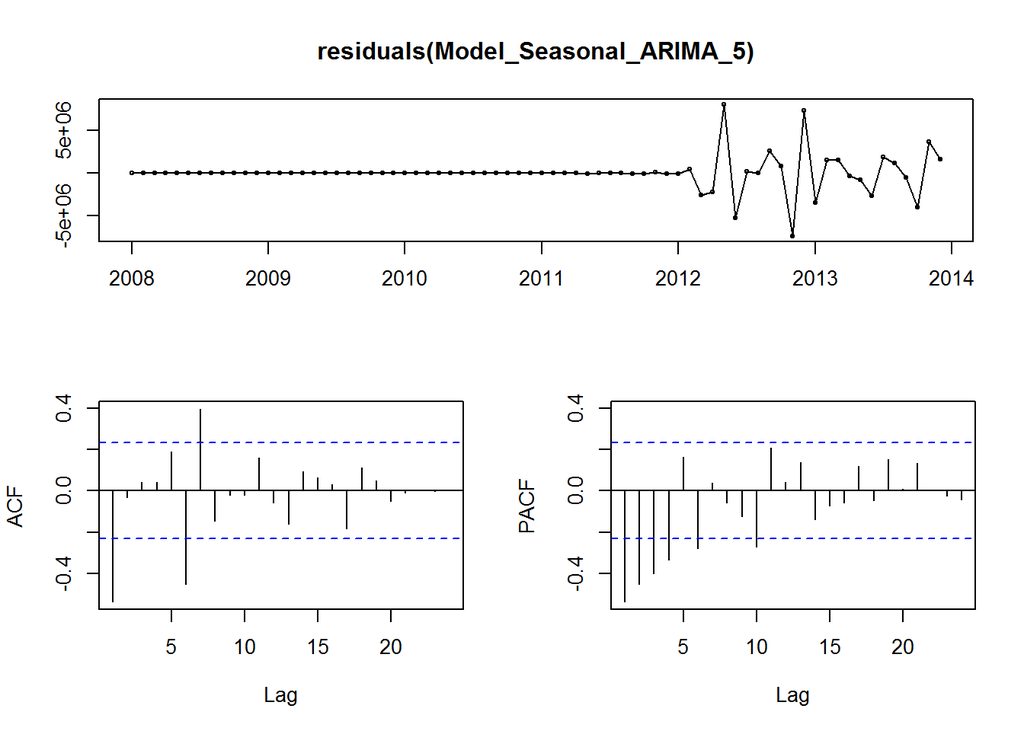

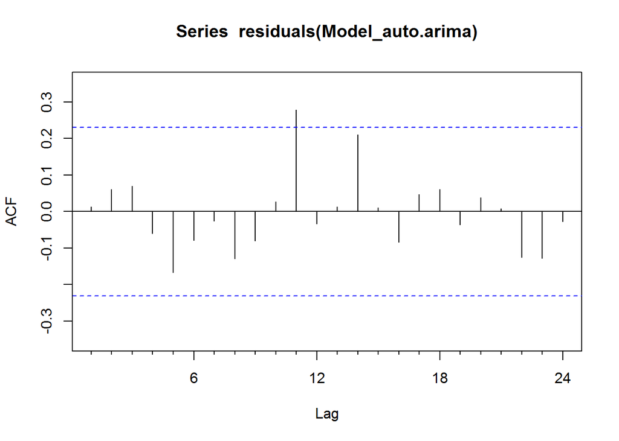

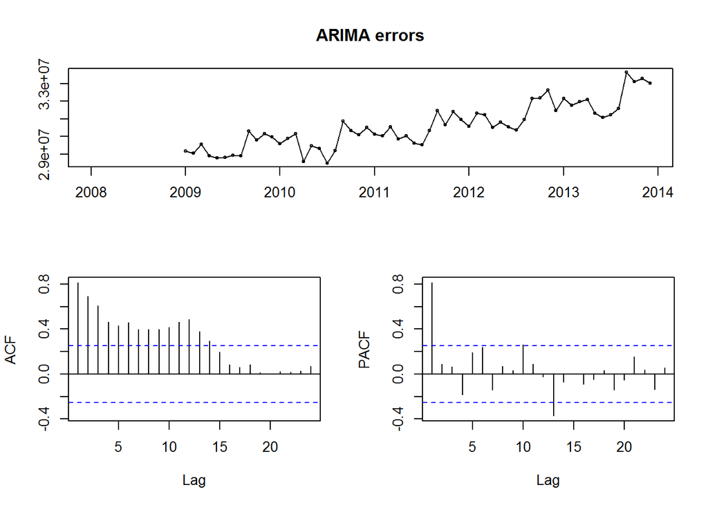

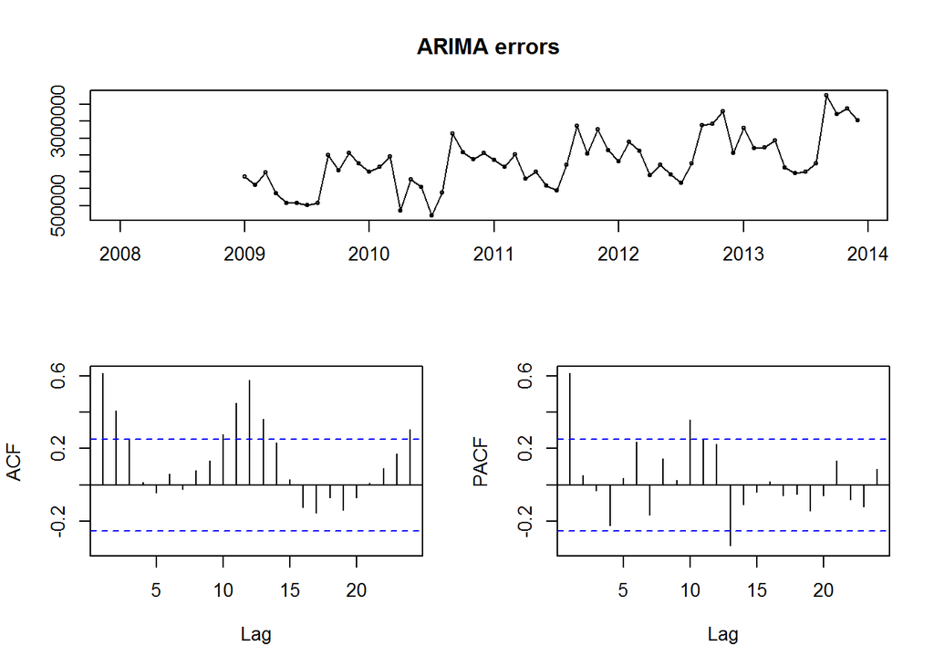

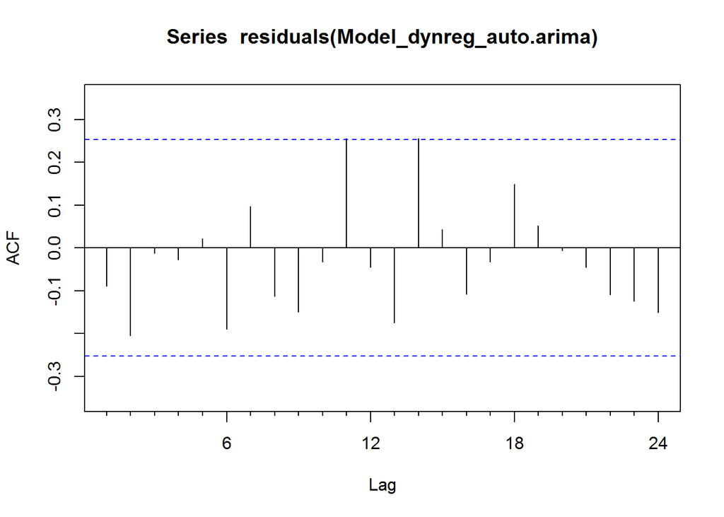

Exponential Smoothing uses past values to calculate a forecast. The strength with which each value influences the forecast is weakened with help of a smoothing parameter. Thus we are dealing with a weighted average, whose values fade out the longer ago they were in the past.

#### Simple expontential smoothing

Formula: ses(). It must be decided if alpha (the smoothing parameter should be automatically calculated. If initial=simple, the alpha value canbe set to any chosen value, if initial=optimal (or nothing, as this is the default), alpha will be set to the optimal value based on ets(). h=12 gives the number of cycles for the forecast.

```r
print(summary(Model_ses))
```

```
##
## Forecast method: Simple exponential smoothing
##
## Model Information:
## Simple exponential smoothing
##
## Call:
##  ses(x = TotalAsIs, h = 12)
##
##   Smoothing parameters:
##     alpha = 0.671
##
##   Initial states:
##     l = 2173226.7433
##
##   sigma:  609507
##
##      AIC     AICc      BIC
## 2230.058 2230.232 2234.612
##
## Error measures:
##                    ME   RMSE      MAE       MPE     MAPE     MASE
## Training set 47469.84 609507 429997.1 -1.511008 15.02336 1.172074
##                    ACF1
## Training set 0.02384493
##
## Forecasts:
##          Point Forecast   Lo 80   Hi 80   Lo 95   Hi 95
## Jan 2014        4466448 3685333 5247562 3271836 5661059
## Feb 2014        4466448 3525801 5407094 3027853 5905042
## Mar 2014        4466448 3389650 5543245 2819628 6113267
## Apr 2014        4466448 3268880 5664015 2634926 6297969
## May 2014        4466448 3159220 5773675 2467215 6465680
## Jun 2014        4466448 3058072 5874823 2312524 6620371
## Jul 2014        4466448 2963718 5969177 2168221 6764674
## Aug 2014        4466448 2874947 6057948 2032458 6900437
## Sep 2014        4466448 2790873 6142022 1903878 7029017
## Oct 2014        4466448 2710821 6222074 1781448 7151447
## Nov 2014        4466448 2634263 6298632 1664363 7268532
## Dec 2014        4466448 2560778 6372117 1551977 7380918
##          Point Forecast   Lo 80   Hi 80   Lo 95   Hi 95
## Jan 2014        4466448 3685333 5247562 3271836 5661059
## Feb 2014        4466448 3525801 5407094 3027853 5905042
## Mar 2014        4466448 3389650 5543245 2819628 6113267
## Apr 2014        4466448 3268880 5664015 2634926 6297969
## May 2014        4466448 3159220 5773675 2467215 6465680
## Jun 2014        4466448 3058072 5874823 2312524 6620371
## Jul 2014        4466448 2963718 5969177 2168221 6764674
## Aug 2014        4466448 2874947 6057948 2032458 6900437
## Sep 2014        4466448 2790873 6142022 1903878 7029017
## Oct 2014        4466448 2710821 6222074 1781448 7151447
## Nov 2014        4466448 2634263 6298632 1664363 7268532
## Dec 2014        4466448 2560778 6372117 1551977 7380918
```

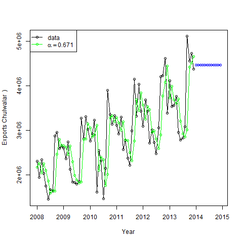

Figure 35

The Akaike’s Information Criterion(AIC/AICc) or the Bayesian Information Criterion (BIC) should be at minimum.

[figure not shown]

Figure 36

##### Holt’s linear trend method:

Holt added to the model in order to forecast using trends as well. For this it is necessary to add a beta, which determines the trend. If neither alpha nor beta is stated, both parameters will be optimised using ets().

```r
print(summary(Model_holt_1))
```

```
##
## Forecast method: Holt's method
##
## Model Information:
## Holt's method
##
## Call:
##  holt(x = TotalAsIs, h = 12)
##
##   Smoothing parameters:
##     alpha = 0.6571
##     beta  = 1e-04
##
##   Initial states:
##     l = 2040390.7764
##     b = 45050.7514
##
##   sigma:  608119.1
##
##      AIC     AICc      BIC
## 2233.730 2234.327 2242.837
##
## Error measures:
##                    ME     RMSE      MAE      MPE     MAPE     MASE
## Training set -16586.9 608119.1 441110.7 -3.88925 15.75307 1.202367
##                    ACF1
## Training set 0.03462672
##
## Forecasts:
##          Point Forecast   Lo 80   Hi 80   Lo 95   Hi 95
## Jan 2014        4536367 3757031 5315703 3344475 5728259
## Feb 2014        4581298 3648703 5513894 3155016 6007580
## Mar 2014        4626230 3562188 5690271 2998918 6253541
## Apr 2014        4671161 3490181 5852141 2865008 6477314
## May 2014        4716092 3428721 6003463 2747228 6684956
## Jun 2014        4761024 3375378 6146669 2641862 6880185
## Jul 2014        4805955 3328531 6283379 2546429 7065480
## Aug 2014        4850886 3287035 6414738 2459182 7242591
## Sep 2014        4895818 3250047 6541588 2378829 7412807
## Oct 2014        4940749 3216925 6664573 2304387 7577111
## Nov 2014        4985680 3187164 6784196 2235088 7736273
## Dec 2014        5030612 3160363 6900860 2170314 7890909
##          Point Forecast   Lo 80   Hi 80   Lo 95   Hi 95
## Jan 2014        4536367 3757031 5315703 3344475 5728259
## Feb 2014        4581298 3648703 5513894 3155016 6007580
## Mar 2014        4626230 3562188 5690271 2998918 6253541
## Apr 2014        4671161 3490181 5852141 2865008 6477314
## May 2014        4716092 3428721 6003463 2747228 6684956
## Jun 2014        4761024 3375378 6146669 2641862 6880185
## Jul 2014        4805955 3328531 6283379 2546429 7065480
## Aug 2014        4850886 3287035 6414738 2459182 7242591
## Sep 2014        4895818 3250047 6541588 2378829 7412807
## Oct 2014        4940749 3216925 6664573 2304387 7577111
## Nov 2014        4985680 3187164 6784196 2235088 7736273
## Dec 2014        5030612 3160363 6900860 2170314 7890909
```

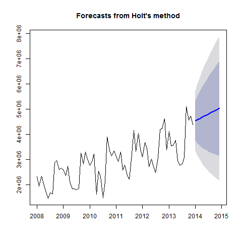

Figure 37

The trend is exponential if the intercepts(level) and the gradient (slope) are multiplied with eachother. The values are worse. As the Beta was very low in the optimisation, the forecast is very similar to the ses() model.

```r
print(summary(Model_holt_2))
```

```
##
## Forecast method: Holt's method with exponential trend
##
## Model Information:
## Holt's method with exponential trend
##
## Call:
##  holt(x = TotalAsIs, h = 12, exponential = TRUE)
##
##   Smoothing parameters:
##     alpha = 0.6637
##     beta  = 1e-04
##
##   Initial states:
##     l = 2041538.9468
##     b = 1.0029
##
##   sigma:  0.2438
##
##      AIC     AICc      BIC
## 2251.010 2251.607 2260.116
##
## Error measures:
##                    ME     RMSE      MAE       MPE     MAPE     MASE
## Training set 37825.61 609787.5 433018.9 -1.838214 15.18487 1.180311
##                    ACF1
## Training set 0.02918287
##
## Forecasts:
##          Point Forecast   Lo 80   Hi 80   Lo 95    Hi 95
## Jan 2014        4488281 3097523 5867539 2306270  6596669
## Feb 2014        4502175 2855923 6245721 2109259  7313443
## Mar 2014        4516113 2651465 6531906 1938416  7861046
## Apr 2014        4530094 2519232 6839637 1871711  8516398
## May 2014        4544118 2404344 7028101 1733147  8941622
## Jun 2014        4558186 2279040 7209036 1578921  9327724
## Jul 2014        4572297 2188374 7363239 1476062  9819000
## Aug 2014        4586452 2074063 7689817 1315739 10444965
## Sep 2014        4600650 2028558 7937851 1323281 10991792
## Oct 2014        4614893 1902891 8048179 1239971 11289444
## Nov 2014        4629180 1836662 8212818 1150990 12078009
## Dec 2014        4643510 1759217 8351084 1102492 12240514
##          Point Forecast   Lo 80   Hi 80   Lo 95    Hi 95
## Jan 2014        4488281 3097523 5867539 2306270  6596669
## Feb 2014        4502175 2855923 6245721 2109259  7313443
## Mar 2014        4516113 2651465 6531906 1938416  7861046
## Apr 2014        4530094 2519232 6839637 1871711  8516398
## May 2014        4544118 2404344 7028101 1733147  8941622
## Jun 2014        4558186 2279040 7209036 1578921  9327724
## Jul 2014        4572297 2188374 7363239 1476062  9819000
## Aug 2014        4586452 2074063 7689817 1315739 10444965
## Sep 2014        4600650 2028558 7937851 1323281 10991792
## Oct 2014        4614893 1902891 8048179 1239971 11289444
## Nov 2014        4629180 1836662 8212818 1150990 12078009
## Dec 2014        4643510 1759217 8351084 1102492 12240514
```

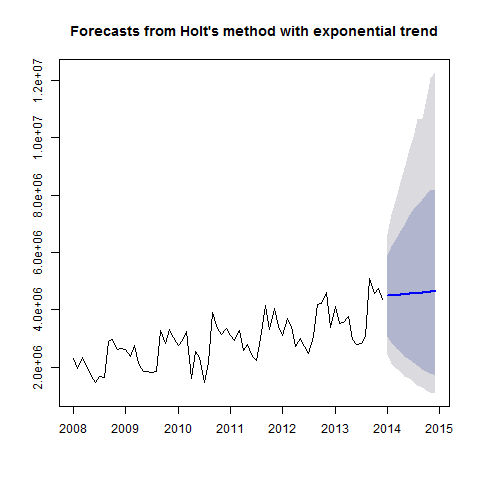

Figure 38

As such simple trends tend to forecast the future to positively, we have added a dampener. Similar values to that of Model_holt_1

```r
summary(Model_holt_3)
```

```
##
## Forecast method: Damped Holt's method
##
## Model Information:
## Damped Holt's method
##
## Call:
##  holt(x = TotalAsIs, h = 12, damped = TRUE)
##
##   Smoothing parameters:
##     alpha = 0.6613
##     beta  = 2e-04
##     phi   = 0.98
##
##   Initial states:
##     l = 2040392.5761
##     b = 45053.25
##
##   sigma:  608787.2
##
##      AIC     AICc      BIC
## 2235.888 2236.797 2247.272
##
## Error measures:
##                    ME     RMSE      MAE       MPE     MAPE     MASE
## Training set 15578.94 608787.2 436909.7 -2.797612 15.46526 1.190916
##                    ACF1
## Training set 0.03351419
##
## Forecasts:
##          Point Forecast   Lo 80   Hi 80   Lo 95   Hi 95
## Jan 2014        4483618 3703426 5263811 3290417 5676819
## Feb 2014        4493914 3558436 5429391 3063224 5924603
## Mar 2014        4504003 3435520 5572486 2869899 6138107
## Apr 2014        4513891 3327168 5700614 2698955 6328827
## May 2014        4523581 3229332 5817829 2544198 6502963
## Jun 2014        4533077 3139534 5926619 2401837 6664316
## Jul 2014        4542383 3056128 6028638 2269352 6815413
## Aug 2014        4551503 2977955 6125051 2144969 6958036
## Sep 2014        4560440 2904162 6216719 2027381 7093499
## Oct 2014        4569199 2834101 6304298 1915595 7222803
## Nov 2014        4577783 2767264 6388301 1808834 7346732
## Dec 2014        4586195 2703249 6469141 1706477 7465913
```

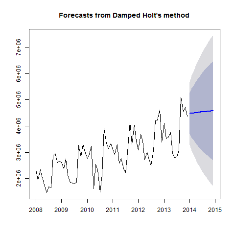

Figure 39

This also works for exponential trends. The values remain worse.

```r
print(summary(Model_holt_4))
```

```
##
## Forecast method: Damped Holt's method with exponential trend
##
## Model Information:
## Damped Holt's method with exponential trend
##
## Call:
##  holt(x = TotalAsIs, h = 12, damped = TRUE, exponential = TRUE)
##
##   Smoothing parameters:
##     alpha = 0.6679
##     beta  = 1e-04
##     phi   = 0.9799
##
##   Initial states:
##     l = 2041541.9705
##     b = 1.0019
##
##   sigma:  0.2449
##
##      AIC     AICc      BIC
## 2253.216 2254.125 2264.600
##
## Error measures:
##                    ME     RMSE      MAE       MPE     MAPE     MASE
## Training set 46119.56 609906.7 432069.1 -1.549114 15.11987 1.177722
##                   ACF1
## Training set 0.0254941
##
## Forecasts:
##          Point Forecast   Lo 80   Hi 80   Lo 95    Hi 95
## Jan 2014        4470648 3066503 5889666 2344747  6638346
## Feb 2014        4473164 2873145 6193829 2091777  7303931
## Mar 2014        4475630 2670353 6482615 1997768  7899225
## Apr 2014        4478047 2516160 6747640 1811127  8456056
## May 2014        4480418 2340287 7011576 1688812  8915810
## Jun 2014        4482742 2239403 7208329 1558211  9244087
## Jul 2014        4485020 2118582 7343646 1403884  9866908
## Aug 2014        4487253 2016226 7473670 1360038 10365973
## Sep 2014        4489443 1913708 7741930 1276951 10738372
## Oct 2014        4491589 1844826 7937351 1192063 11235713
## Nov 2014        4493694 1773815 8183394 1103755 11357454
## Dec 2014        4495757 1672522 8141431 1048147 11858154
##          Point Forecast   Lo 80   Hi 80   Lo 95    Hi 95
## Jan 2014        4470648 3066503 5889666 2344747  6638346
## Feb 2014        4473164 2873145 6193829 2091777  7303931
## Mar 2014        4475630 2670353 6482615 1997768  7899225
## Apr 2014        4478047 2516160 6747640 1811127  8456056
## May 2014        4480418 2340287 7011576 1688812  8915810
## Jun 2014        4482742 2239403 7208329 1558211  9244087
## Jul 2014        4485020 2118582 7343646 1403884  9866908
## Aug 2014        4487253 2016226 7473670 1360038 10365973
## Sep 2014        4489443 1913708 7741930 1276951 10738372
## Oct 2014        4491589 1844826 7937351 1192063 11235713
## Nov 2014        4493694 1773815 8183394 1103755 11357454
## Dec 2014        4495757 1672522 8141431 1048147 11858154
```

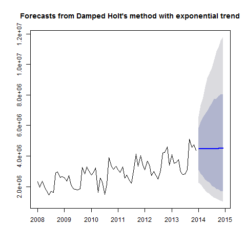

Figure 40

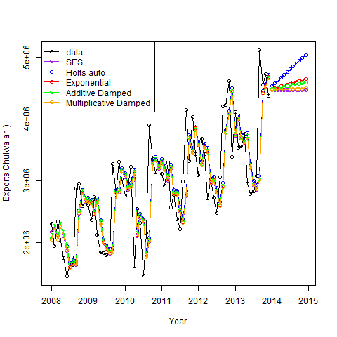

Figure 41

As these forecasts are not very convincing at the moment, there is no need to export the data.

#### Holt-Winter’s Seasonal Method

Holt and Winters have expanded Holt’s model further to include the seasonality aspect. The parameter gamma, which is for smoothing the seasonality, was added to achieve this. The values are better than the models without seasonality. This logical matches our results from the regression approaches, the data is strongly influenced by seasonality. In the following model, none of the parameters are given so that they will be optimised automatically. There are two models: one using an additive error model method and one using a multiplicative error model.

```r
print(summary(Model_hw_1))
```

```
##
## Forecast method: Holt-Winters' additive method
##
## Model Information:
## Holt-Winters' additive method
##
## Call:
##  hw(x = TotalAsIs, h = 12, seasonal = "additive")
##
##   Smoothing parameters:
##     alpha = 0.0087
##     beta  = 0.0087
##     gamma = 1e-04
##
##   Initial states:
##     l = 2047375.0884
##     b = 22509.7631
##     s=259168.3 654942.6 474529.8 876025.2 -475155 -852844
##            -664662.5 -412596.7 -438677.3 273215 138077.9 167976.7
##
##   sigma:  241685
##
##      AIC     AICc      BIC
## 2124.856 2134.747 2161.283
##
## Error measures:
##                    ME   RMSE      MAE         MPE     MAPE      MASE
## Training set 21615.43 241685 202218.5 -0.08252109 7.329458 0.5512016
##                    ACF1
## Training set -0.2819072
##
## Forecasts:
##          Point Forecast   Lo 80   Hi 80   Lo 95   Hi 95
## Jan 2014        4141204 3831472 4450936 3667510 4614898
## Feb 2014        4147309 3837472 4457147 3673453 4621165
## Mar 2014        4318537 4008512 4628563 3844394 4792680
## Apr 2014        3642744 3332425 3953063 3168153 4117335
## May 2014        3704865 3394124 4015605 3229628 4180102
## Jun 2014        3488859 3177546 3800173 3012746 3964973
## Jul 2014        3336738 3024677 3648799 2859482 3813994
## Aug 2014        3750478 3437474 4063482 3271780 4229176
## Sep 2014        5137771 4823607 5451935 4657298 5618244
## Oct 2014        4772337 4456775 5087900 4289726 5254949
## Nov 2014        4988809 4671591 5306028 4503665 5473953
## Dec 2014        4629097 4309943 4948252 4140992 5117202
##          Point Forecast   Lo 80   Hi 80   Lo 95   Hi 95
## Jan 2014        4141204 3831472 4450936 3667510 4614898
## Feb 2014        4147309 3837472 4457147 3673453 4621165
## Mar 2014        4318537 4008512 4628563 3844394 4792680
## Apr 2014        3642744 3332425 3953063 3168153 4117335
## May 2014        3704865 3394124 4015605 3229628 4180102
## Jun 2014        3488859 3177546 3800173 3012746 3964973
## Jul 2014        3336738 3024677 3648799 2859482 3813994
## Aug 2014        3750478 3437474 4063482 3271780 4229176
## Sep 2014        5137771 4823607 5451935 4657298 5618244
## Oct 2014        4772337 4456775 5087900 4289726 5254949
## Nov 2014        4988809 4671591 5306028 4503665 5473953
## Dec 2014        4629097 4309943 4948252 4140992 5117202
```

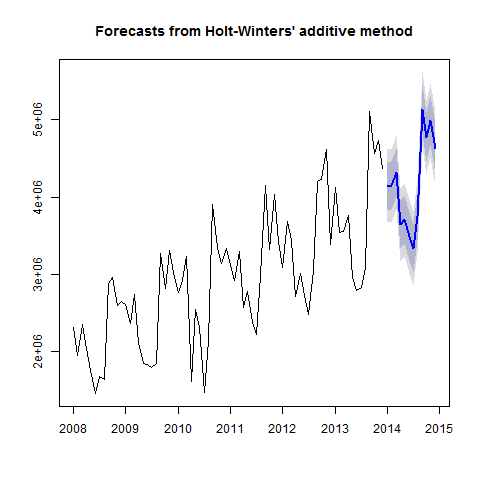

Figure 42

```r
#     AIC     AICc      BIC
#2127.984 2137.875 2164.411
```

```r
print(summary(Model_hw_2))
```

```
##
## Forecast method: Holt-Winters' multiplicative method
##
## Model Information:
## Holt-Winters' multiplicative method
##
## Call:
##  hw(x = TotalAsIs, h = 12, seasonal = "multiplicative")
##
##   Smoothing parameters:
##     alpha = 0.025
##     beta  = 0.0062
##     gamma = 1e-04
##
##   Initial states:
##     l = 2026247.531
##     b = 25395.1259
##     s=1.0933 1.232 1.1763 1.3086 0.8384 0.699
##            0.7653 0.8502 0.8596 1.0793 1.0316 1.0665
##
##   sigma:  0.0877
##
##      AIC     AICc      BIC
## 2128.303 2138.194 2164.729
##
## Error measures:
##                    ME     RMSE      MAE        MPE     MAPE      MASE
## Training set 17434.11 235296.6 191805.3 -0.3292809 7.213472 0.5228175
##                    ACF1
## Training set -0.3514421
##
## Forecasts:
##          Point Forecast   Lo 80   Hi 80   Lo 95   Hi 95
## Jan 2014        4226941 3751624 4702258 3500006 4953876
## Feb 2014        4123665 3659738 4587591 3414151 4833179
## Mar 2014        4350808 3860995 4840620 3601704 5099911
## Apr 2014        3494208 3100476 3887940 2892046 4096370
## May 2014        3484738 3091618 3877858 2883513 4085963
## Jun 2014        3162774 2805463 3520085 2616314 3709234
## Jul 2014        2912399 2582802 3241996 2408324 3416474
## Aug 2014        3521645 3122278 3921013 2910865 4132425
## Sep 2014        5540988 4911109 6170867 4577671 6504304
## Oct 2014        5020487 4448200 5592775 4145249 5895725
## Nov 2014        5299729 4693715 5905743 4372911 6226547
## Dec 2014        4740169 4196230 5284108 3908286 5572052
##          Point Forecast   Lo 80   Hi 80   Lo 95   Hi 95
## Jan 2014        4226941 3751624 4702258 3500006 4953876
## Feb 2014        4123665 3659738 4587591 3414151 4833179
## Mar 2014        4350808 3860995 4840620 3601704 5099911
## Apr 2014        3494208 3100476 3887940 2892046 4096370
## May 2014        3484738 3091618 3877858 2883513 4085963
## Jun 2014        3162774 2805463 3520085 2616314 3709234
## Jul 2014        2912399 2582802 3241996 2408324 3416474
## Aug 2014        3521645 3122278 3921013 2910865 4132425
## Sep 2014        5540988 4911109 6170867 4577671 6504304
## Oct 2014        5020487 4448200 5592775 4145249 5895725
## Nov 2014        5299729 4693715 5905743 4372911 6226547
## Dec 2014        4740169 4196230 5284108 3908286 5572052
```

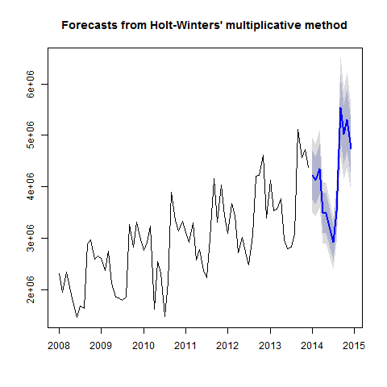

Figure 43

```r
#     AIC     AICc      BIC
#2137.673 2147.564 2174.100
```

The additive model gives slightly better results than the multiplicative model.

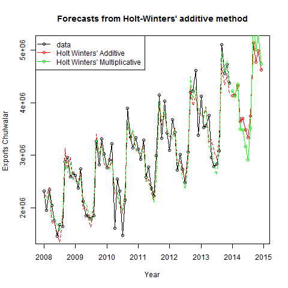

Figure 44

In order to use the results later, they need to be converted into point forcasts.

```r
print(head(Model_hw_1_PointForecast))
```

```
## [1] 4141204 4147309 4318537 3642744 3704865 3488859
```

```r
print(head(Model_hw_2_PointForecast))
```

```
## [1] 4226941 4123665 4350808 3494208 3484738 3162774
```

#### Innovations state space models for exponential smoothing

The funktion ets() produces a model with the same values as Model_hw_1. The reason for this is that all of the parameters in this model were optimised using the ets() function. The results are a ets(A,A,A) model which is anadditive method for trend, seasonality and errors. The previous models also showed the type of ets() model in their summary. In this case the user parameters were either accepted or rejected. As the model has been set to “ZZZ”, the best model will be automatically chosen.

```r
print(summary(Model_ets))
```

```
## ETS(A,A,A)
##
## Call:
##  ets(y = TotalAsIs, model = "ZZZ", damped = NULL, alpha = NULL,
##
##  Call:
##      beta = NULL, gamma = NULL, phi = NULL, additive.only = FALSE,
##
##  Call:
##      lambda = NULL, lower = c(rep(1e-04, 3), 0.8), upper = c(rep(0.9999,
##
##  Call:
##          3), 0.98), opt.crit = c("lik", "amse", "mse", "sigma",
##
##  Call:
##          "mae"), nmse = 3, bounds = c("both", "usual", "admissible"),
##
##  Call:
##      ic = c("aicc", "aic", "bic"), restrict = TRUE)
##
##   Smoothing parameters:
##     alpha = 0.0087
##     beta  = 0.0087
##     gamma = 1e-04
##
##   Initial states:
##     l = 2047375.0885
##     b = 22509.7629
##     s=259168.3 654942.6 474529.8 876025.2 -475155 -852844
##            -664662.5 -412596.7 -438677.3 273215 138077.9 167976.7
##
##   sigma:  241685.1
##
##      AIC     AICc      BIC
## 2124.856 2134.747 2161.283
##
## Training set error measures:
##                    ME     RMSE      MAE         MPE     MAPE      MASE
## Training set 21587.58 241685.1 202221.1 -0.08332944 7.329631 0.5512087
##                    ACF1
## Training set -0.2818997
##                    ME     RMSE      MAE         MPE     MAPE      MASE
## Training set 21587.58 241685.1 202221.1 -0.08332944 7.329631 0.5512087
##                    ACF1
## Training set -0.2818997
```

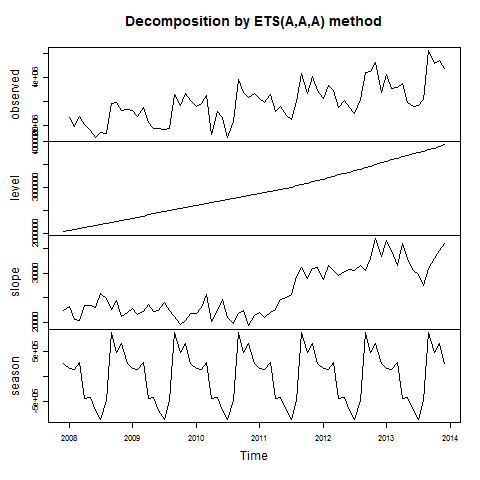

Figure 45

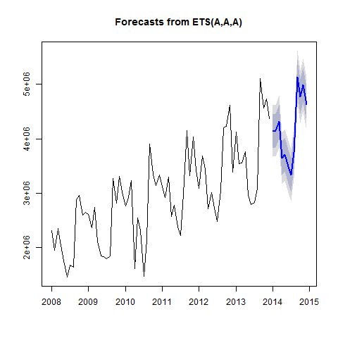

Figure 46

```r
#     AIC     AICc      BIC
#2127.984 2137.875 2164.411
```

In order to use the results later, they need to be converted into point forcasts.

```r
head(Model_ets_PointForecast)
```

```
## [1] 4141260 4147361 4318585 3642788 3704905 3488896
```

### 8.2 ARIMA

#### AR = Autoregression

A Regression of a variable with itself. The autoregressive model specifies that the output variable depends linearly on its own previous values.

#### MA = Moving Average

The rolling average of past forecast errors. This model should not be confused with moving average smoothing, which is used for establishing trends and is based on past values.

#### ARIMA = AutoRegressive Integrated Moving Average model A combination of Differencing, Autoregression and Moving Average. Integration is the opposite of differencing.

#### Differencing

In order to make the time series stationary, it is necessary to difference. Firstly, we need to check if the data are already stationary. This can be done with help of the Augmented Dickey-Fuller Test

```r
print(adf.test(TotalAsIs, alternative = "stationary"))
```

```
##
##  Augmented Dickey-Fuller Test
##
## data:  TotalAsIs
## Dickey-Fuller = -5.8915, Lag order = 4, p-value = 0.01
## alternative hypothesis: stationary
```

The p-value is less than 0,05. This means that the data is stationary, as the 0-Hypothesis of the test is “The data are not stationary”. Another possibility is the Kwiatkowski-Phillips-Schmidt-Shin Test

```r
print(kpss.test(TotalAsIs))
```

```
## Warning in kpss.test(TotalAsIs): p-value smaller than printed p-value
```

```
##
##  KPSS Test for Level Stationarity
##
## data:  TotalAsIs
## KPSS Level = 2.0548, Truncation lag parameter = 1, p-value = 0.01
```

This test swaps the hypothesis so that a low p-value means that it is necessary to difference. The p-value here is under 0,01 and a warning is shown.  
As the test failed to deliver a clear result, the data will be differencedand then retested.

```r
print(adf.test(ChulwalarDiff, alternative = "stationary"))
```

```
## Warning in adf.test(ChulwalarDiff, alternative = "stationary"): p-value
## smaller than printed p-value
```

```
##
##  Augmented Dickey-Fuller Test
##
## data:  ChulwalarDiff
## Dickey-Fuller = -6.2758, Lag order = 4, p-value = 0.01
## alternative hypothesis: stationary
```

```r
print(kpss.test(ChulwalarDiff))
```

```
##
##  KPSS Test for Level Stationarity
##
## data:  ChulwalarDiff
## KPSS Level = 0.024179, Truncation lag parameter = 1, p-value = 0.1
```

The kpss.test now has a p-value of more than 0,1, which hints that the data is stationary.

```r
print(tsdisplay(ChulwalarDiff))
```

[output not shown]

However this plot shows that the months correlate stongly with the values from the previous year. This plot shows a ACF (autocorrelation function) and a PACF (partial autocorrelation function).  
The folling is a test method to distinguish the number of “normal” differencing rounds and seasonal differencing rounds. Seasonal differencing is used for data which is dominated by seasonality. The time series has been assigned a lag.

```r
nd # Number of normal differencing rounds
```

```
## [1] 0
```

```r
ns # Number of seasonal differencing rounds
```

```
## [1] 1
```

```r
xstar # The output "xstar" has been differenced correctly.
```

```
##          Jan     Feb     Mar     Apr     May     Jun     Jul     Aug
## 2009  297352  421196  397151   85521   93109  377920  117674  212298
## 2010  150115  547006  483255 -511420  700084  481423 -323167  296553
## 2011  352173    8330   67743  963191  223911   60582  748756  843266
## 2012  -19773  752645  138580  137820  237699  347801  260934   63868
## 2013 1026438 -143564  127610 1045166  -51834   61870  344910   28458
##          Sep     Oct     Nov     Dec
## 2009  388285 -140828  714282  365945
## 2010  627400  530065 -174831  310373
## 2011  252960  -30269  901131   96957
## 2012   49265  910040  581464  -46170
## 2013  906979  333420  110773  988508
```

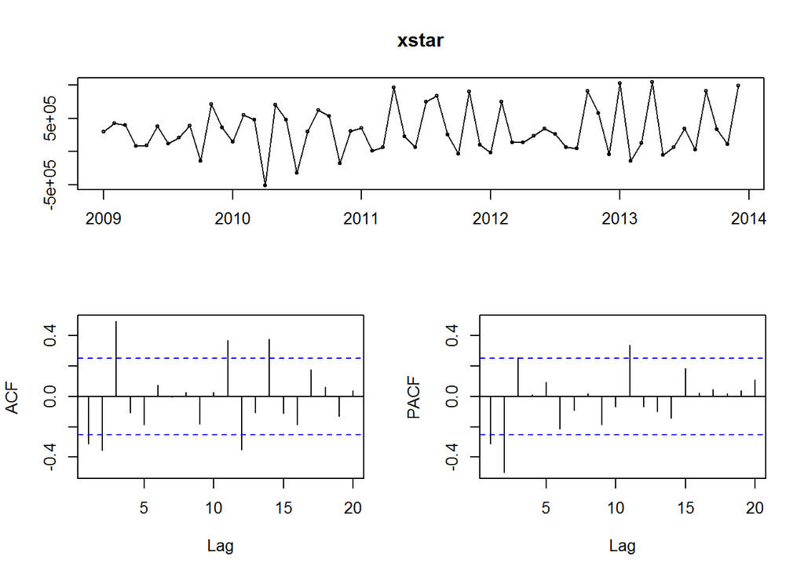

```r
print(tsdisplay(xstar))
```

If “lag” is set to 12, this is equivalent to 1* seasonal differencing

```r
print(adf.test(ChulwalarDiff_lag, alternative = "stationary"))
```

```
##
##  Augmented Dickey-Fuller Test
##
## data:  ChulwalarDiff_lag
## Dickey-Fuller = -4.0902, Lag order = 3, p-value = 0.01175
## alternative hypothesis: stationary
```

```r
print(kpss.test(ChulwalarDiff_lag))
```

```
##
##  KPSS Test for Level Stationarity
##
## data:  ChulwalarDiff_lag
## KPSS Level = 0.13387, Truncation lag parameter = 1, p-value = 0.1
```

```r
print(tsdisplay(ChulwalarDiff))
```

[output not shown]

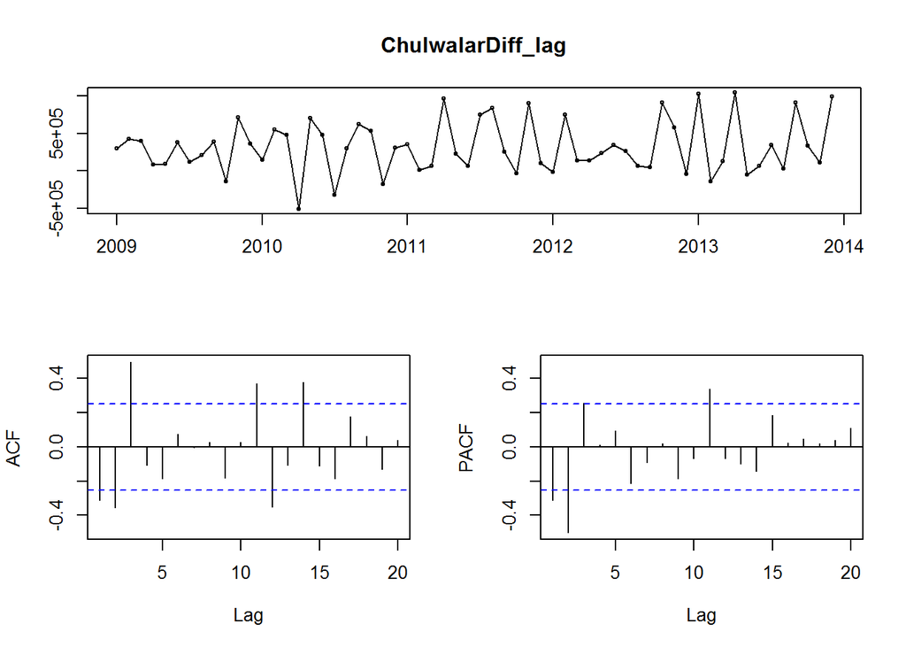

```r
print(tsdisplay(ChulwalarDiff_lag))
```

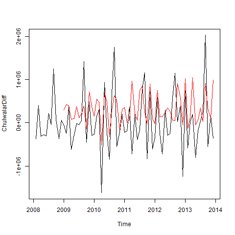

Figure 47

The time series appears much more “stationary”.